# Count Models II

Author

Affiliation

Dave Clark

Binghamton University

Published

October 25, 2026

# Goals

How many militarized disputes does a pair of states have? For most pairs, none — and there are two very different reasons a pair might have none. Some pairs could fight and don’t. Others never had the chance: Paraguay and Mongolia were not going to have a militarized dispute in 1970, whatever either government wanted. Two processes, one observed outcome. This week:

- **Mixtures**: the negative binomial was one; zero-inflated and hurdle models are another kind.
- The **zero-inflated** Poisson and negative binomial: the PMF, the likelihood, and estimation.
- The **hurdle** model, and the fact that the Poisson is already a hurdle model with its two parts tied together.
- Choosing between them, interpreting two equations at once, and estimating which zeros are which.
- What identifies the split between the two processes — and a look back at a zero-inflated model published twenty years ago.

## The process

**Building a maximum likelihood model**

1. **Observe** $y$; consider its distribution; write down its PMF. This week, the distribution is a **mixture** of two distributions — a binary one and a count.
2. **Write the joint probability of the data** under that distribution.
3. **Rewrite the joint probability as a likelihood.**
4. **Simplify** — take logs.
5. **Parameterize** — and now there are *two* parameters to parameterize: the probability that governs the binary part, and the rate, $\lambda$, that governs the count. Each gets its own covariates.
6. **Choose link functions** — a logit (or probit, or cloglog) for the probability, the exponential for the rate.

The punchline up front: every model in these notes is a binary model and a count model glued together. In the **hurdle** model, every zero comes from the binary model. In the **zero-inflated** model, zeros come from *both* parts — a group that can only ever be zero, and the count process, which can produce a zero by chance. That one difference determines the likelihood, how the model is estimated, and what the binary part’s coefficients mean.

# Opportunity and willingness

Let’s motivate this by thinking about how militarized conflict comes about and between whom. Most and Starr (1989) argue that conflict requires both **opportunity** — the ability to reach and interact with another state — and **willingness** — the choice to fight. Opportunity is hard to measure, and the usual fix is to throw out the pairs that seem to lack it. The common rule in the interstate conflict literature keeps **politically relevant dyads**: pairs that are contiguous or include a major power (Lemke and Reed 2001). The democratic peace data we’ve used all semester (`dp.dta`) contain relevant dyads only. This practice imposes by rule a binary model of opportunity - dyads that are relevant have opportunity and stay in the model. The models this week *estimate* opportunity instead of using the (poor) proxy of political relevance (Clark and Regan 2003). It turns out that there are disputes in “irrelevant” dyads, and surely there are “relevant” dyads that don’t have disputes because they structurally cannot. The goal is to estimate those differences.

## All dyads

To start, we need all pairs of states, not just the relevant ones. `peacesciencer` (Miller 2022) builds every dyad-year in the Correlates of War state system and attaches the variables we need, including the Gibler–Miller–Little dispute data (Gibler, Miller, and Little 2016). I keep the democratic peace data’s window, 1951–1985, and collapse to one row per dyad: the $y$ variable is the number of MID onsets each year, with the number of years both states existed as the exposure.

```r
# every pair of states in the COW system, 1951-1985, one row per dyad-year, with
# MID onsets, contiguity, capital distance, major powers, capabilities, Polity
dyad_years <- create_dyadyears(system = "cow", directed = FALSE, subset_years = 1951:1985) %>%
  add_gml_mids(keep = NULL) %>%
  add_contiguity() %>%
  add_capital_distance() %>%
  add_cow_majors() %>%
  add_nmc() %>%
  add_democracy()

# one row per dyad: MID onsets over the period, years both states existed
# (the exposure), and covariates averaged (or, for the indicators, maxed)
dy <- dyad_years %>%
  mutate(contig = as.integer(conttype %in% 1:5),          # land or water <= 400 miles
         major = as.integer(cowmaj1 == 1 | cowmaj2 == 1),
         lcapratio = log(pmax(cinc1, cinc2) / pmin(cinc1, cinc2)),
         demmin = pmin(polity21, polity22)) %>%
  group_by(ccode1, ccode2) %>%
  summarize(mids = sum(gmlmidonset, na.rm = TRUE), years = n(),
            contig = max(contig), major = max(major),
            lcapdist = log(mean(capdist) + 1),
            lcapratio = mean(lcapratio[is.finite(lcapratio)]),
            demmin = mean(demmin, na.rm = TRUE), .groups = "drop") %>%
  drop_na() %>%
  filter(is.finite(lcapratio)) %>%
  mutate(lyears = log(years),
         relevant = as.integer(contig == 1 | major == 1))

n_all_dyads <- nrow(distinct(dyad_years, ccode1, ccode2))

dy_labels <- c("demmin" = "Democracy (lower Polity score)",
               "lcapratio" = "ln(capability ratio)",
               "contig" = "Contiguous",
               "lcapdist" = "ln(capital distance)",
               "major" = "Major power in dyad",
               "(Intercept)" = "Constant")

# share of dyads with any MID by fifths of capital distance, relevant and not
look_dist <- dy %>%
  mutate(dist_fifth = ntile(lcapdist, 5),
         group = if_else(relevant == 1, "Politically relevant", "Other dyads")) %>%
  group_by(group, dist_fifth) %>%
  summarize(share = mean(mids > 0), .groups = "drop")
```

That’s 288,075 dyad-years and 10,432 dyads (2,708 more drop out for lack of Polity scores). Only 1,055 are politically relevant. 96.5% of dyads have no MIDs at all; the most active dyad has 25 (the US-USSR dyad).

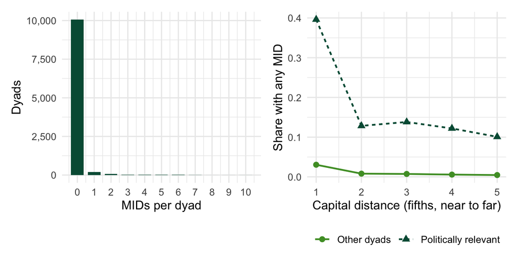

Figure 1: Left: MID onsets per dyad, 1951-1985 (counts above 10 not shown). Right: share of dyads with any MID, by capital distance (fifths of the distribution), for politically relevant and other dyads.

```r
p_hist <- dy %>% filter(mids <= 10) %>%
  ggplot(aes(x = mids)) +
  geom_bar(fill = bu_green, width = .75) +
  scale_x_continuous(breaks = 0:10) +
  scale_y_continuous(labels = scales::comma) +
  labs(x = "MIDs per dyad", y = "Dyads") +
  theme_bu()

p_dist <- ggplot(look_dist, aes(x = dist_fifth, y = share, color = group, linetype = group, shape = group)) +
  geom_line(linewidth = .8) +
  geom_point(size = 2.4) +
  scale_color_manual(values = c(bu_lightgreen, bu_green)) +
  labs(x = "Capital distance (fifths, near to far)", y = "Share with any MID",
       color = NULL, linetype = NULL, shape = NULL) +
  theme_bu() +
  theme(legend.position = "bottom")

p_hist + p_dist
```

The zeros swamp everything, and the dyads with any MID are concentrated among the relevant pairs. Is a distant pair with no MIDs a low-rate version of a near pair, or a pair that was never in the game?

## Rootograms

A **hanging rootogram** [Kleiber and Zeileis (2016); the idea goes back to Tukey] plots the *square root* of the frequencies, so misses away from the zero bar stay visible, and *hangs* each observed bar from the model’s expected frequency. Read it along the zero line: a bar that stops above the line is a count the model over-predicts; a bar that dips below is one it under-predicts.

```r
# expected frequency of each count 0..maxj: the sum over observations of each
# observation's predicted probability of that count
expected_freq <- function(pmat) colSums(pmat)

# predicted-probability matrices, one row per observation, one column per count
pmat_pois <- function(lambda, maxj) outer(lambda, 0:maxj, function(l, j) dpois(j, l))
pmat_nb   <- function(lambda, alpha, maxj) outer(lambda, 0:maxj, function(l, j) dnbinom(j, mu = l, size = 1 / alpha))

# rootogram data: observed and expected frequencies on the square-root scale;
# each observed bar hangs from the expected value
root_data <- function(y, pmat, maxj) {
  tibble(j = 0:maxj,
         observed = map_dbl(0:maxj, ~ sum(y == .x)),
         expected = expected_freq(pmat)) %>%
    mutate(top = sqrt(expected), bottom = sqrt(expected) - sqrt(observed))
}

hanging_root <- function(rd) {
  ggplot(rd, aes(x = j)) +
    geom_rect(aes(xmin = j - .4, xmax = j + .4, ymin = bottom, ymax = top),
              fill = bu_palegreen, color = bu_green, linewidth = .3) +
    geom_line(aes(y = top), color = bu_black, linewidth = .8) +
    geom_point(aes(y = top), color = bu_black, size = 1.6) +
    geom_hline(yintercept = 0, color = bu_grey, linewidth = .6) +
    labs(x = "Count, j", y = "sqrt(frequency)") +
    theme_bu()
}

# count equation: willingness and opportunity both; exposure is years in the system
dy_f <- mids ~ demmin + lcapratio + contig + lcapdist + major + offset(lyears)

dy_p  <- glm(dy_f, data = dy, family = poisson(link = "log"))
dy_nb <- glm.nb(dy_f, data = dy)
alpha_dy <- 1 / dy_nb$theta
```

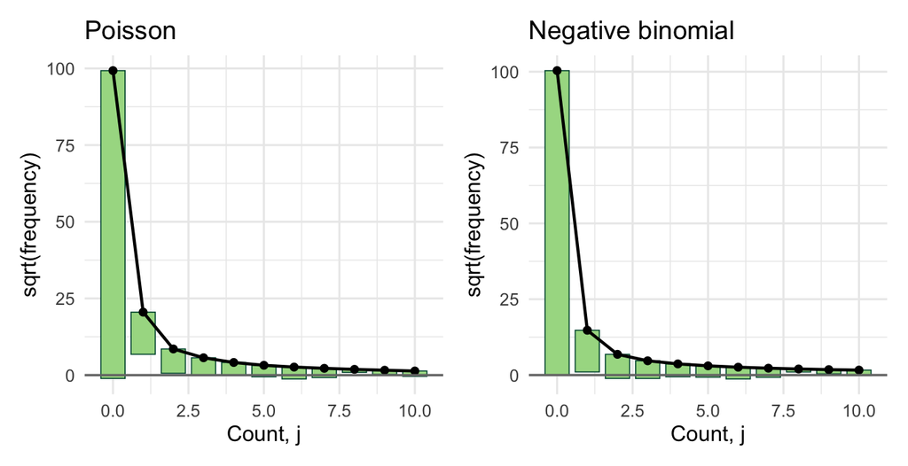

Figure 2: Hanging rootograms, MIDs per dyad, counts 0 to 10. Bars are observed frequencies hanging from the model’s expected frequencies (the line); both on the square-root scale. Left: Poisson. Right: negative binomial.

```r
rd_p  <- root_data(dy$mids, pmat_pois(fitted(dy_p), 10), 10)
rd_nb <- root_data(dy$mids, pmat_nb(fitted(dy_nb), alpha_dy, 10), 10)

(hanging_root(rd_p) + labs(title = "Poisson")) +
  (hanging_root(rd_nb) + labs(title = "Negative binomial"))
```

The Poisson over-estimates the single event dyads. The negative binomial fits the counts, zeros included: it predicts 10,072 zeros against 10,071 observed. If the only question were whether a model can fit the zeros, we could stop here.

But look at *how* the negative binomial fits them. Its $\widehat\alpha$ is 4.80 — very large — because the zeros and the handful of very active dyads sit at opposite ends of one distribution, and $\alpha$ stretches that distribution until both ends fit. The zeros are treated as noise around a single rate for each dyad, and their cost is absorbed by a nuisance parameter. Every dyad still gets a positive rate of conflict; Paraguay and Mongolia just get a very small one.

The theory says something different: some dyads have *no* opportunity, and which ones, and why, is a question we care about. Fitting the zeros is not the same as measuring where they come from. A zero-inflated model takes part of what $\alpha$ absorbs and gives it an equation of its own, with covariates and coefficients we can interpret — a theoretical part of the data generating process, measured, rather than a nuisance soaked up in $\alpha$. So don’t expect a better rootogram from the models below. Expect estimates of opportunity.

# Heterogeneity

What do we mean exactly by heterogeneity?

- events/periods are qualitatively different such that we cannot expect the same process to produce them all.
- put differently, events are drawn from different distributions of events; different means, variances, or both.
- if the means are different, $\beta$ blends the two processes and is biased; below, the negative binomial’s coefficient on distance turns out to be mostly an opportunity effect.
- if the variances are different, the model suffers something like heteroskedasticity.

Some examples of events or periods from different distributions:

- World War II, Vietnam, the Franco-Prussian War, the Football War — vary on magnitude, participants, rules, weaponry.
- Relevant, irrelevant dyads — imperfect measurement; split outcomes; continuous latent variable.
- Taylor Swift concerts attended — varies in times on tour, proximity to event.

Different distributions imply different data generating processes and that we need to think about models with two parts, potentially two equations. This sort of thinking characterizes event count, hazard, censored, selection, and seemingly unrelated regression models. The focus here is on count models where the observed count is generated by multiple processes.

# Where do the zeros come from?

The common empirical indicator of multiple DGPs is excess zeros. But excess zeros do not guarantee two processes are at work, nor that we know what they are even if they do. Short version: use these if your theory indicates parallel processes at work, not merely because the data are dominated by zeros.

## Split populations

Suppose two processes generate the count. One decides whether a unit has *any* chance of events; the other decides *how many* it has. What the second process can produce is the difference between the two models below in Figure 3.

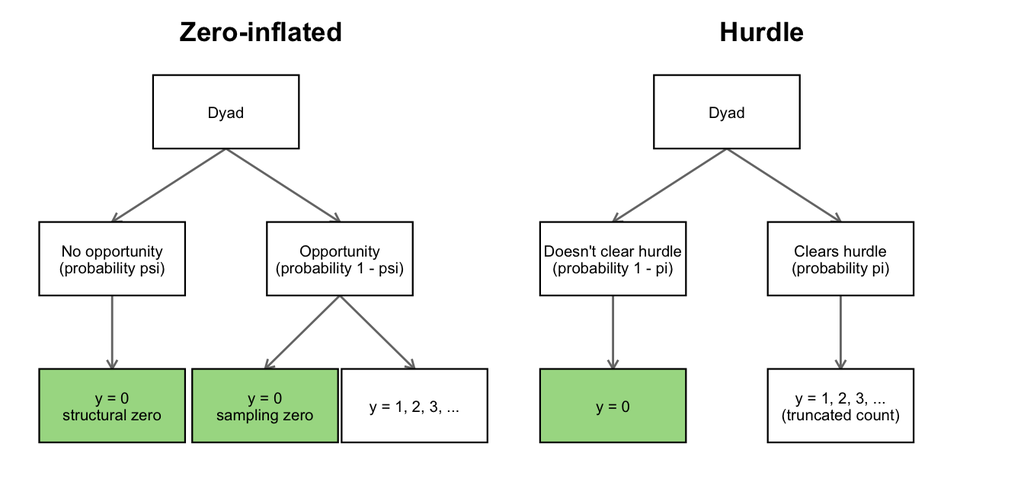

Figure 3: How each model produces a count. Shaded boxes are zeros.

```r
# boxes (centers, labels, whether the box is a zero) and arrows for each tree
box <- function(x, y, label, zero = FALSE) tibble(x, y, label, zero)

zi_boxes <- bind_rows(box(2.2, 4, "Dyad"),
                      box(0.6, 2.4, "No opportunity\n(probability psi)"),
                      box(3.8, 2.4, "Opportunity\n(probability 1 - psi)"),
                      box(0.6, 0.8, "y = 0\nstructural zero", TRUE),
                      box(2.75, 0.8, "y = 0\nsampling zero", TRUE),
                      box(4.85, 0.8, "y = 1, 2, 3, ..."))
zi_arrows <- tribble(~x, ~y, ~xend, ~yend,
                     2.2, 3.6, 0.6, 2.8,   2.2, 3.6, 3.8, 2.8,
                     0.6, 2.0, 0.6, 1.2,   3.8, 2.0, 2.75, 1.2,   3.8, 2.0, 4.85, 1.2)

hu_boxes <- bind_rows(box(2.2, 4, "Dyad"),
                      box(0.6, 2.4, "Doesn't clear hurdle\n(probability 1 - pi)"),
                      box(3.8, 2.4, "Clears hurdle\n(probability pi)"),
                      box(0.6, 0.8, "y = 0", TRUE),
                      box(3.8, 0.8, "y = 1, 2, 3, ...\n(truncated count)"))
hu_arrows <- tribble(~x, ~y, ~xend, ~yend,
                     2.2, 3.6, 0.6, 2.8,   2.2, 3.6, 3.8, 2.8,
                     0.6, 2.0, 0.6, 1.2,   3.8, 2.0, 3.8, 1.2)

tree <- function(boxes, arrows, title) {
  ggplot() +
    geom_segment(data = arrows, aes(x = x, y = y, xend = xend, yend = yend),
                 arrow = arrow(length = unit(.18, "cm")), color = bu_grey) +
    geom_tile(data = boxes, aes(x = x, y = y, fill = zero), width = 2.05, height = .8,
              color = bu_black, linewidth = .4) +
    geom_text(data = boxes, aes(x = x, y = y, label = label), size = 2.7, color = bu_black, lineheight = .9) +
    scale_fill_manual(values = c(`FALSE` = "white", `TRUE` = bu_palegreen), guide = "none") +
    coord_cartesian(xlim = c(-0.5, 5.9), ylim = c(0.3, 4.5)) +
    labs(title = title) +
    theme_void() +
    theme(plot.title = element_text(hjust = .5, face = "bold"))
}

tree(zi_boxes, zi_arrows, "Zero-inflated") + tree(hu_boxes, hu_arrows, "Hurdle")
```

In the **zero-inflated** model, a dyad with opportunity can still have no disputes, so there are two kinds of zero: **structural zeros** from dyads that never had the chance, and **sampling zeros** from dyads that had it and didn’t fight. In the **hurdle** model, clearing the hurdle means at least one event, so every zero comes from the binary part. Either way, we can’t look at a zero and see which branch it came from. The split is **latent**, like $y^*$ in the binary models.

Opportunity and willingness is a zero-inflated story: a pair of neighbors can go thirty years without a dispute. So is fishing at a particular lake (from Greene via Zorn (1998), 372) — some people prefer other lakes, some hate fish. So are US uses of force, where potential targets can see when a president needs a rally and avoid giving the president one (Clark 2003); we’ll come back to that one at the end. Bagozzi (2015) argues civil conflict data are full of structural zeros; Casiraghi and Cusumano (2024) use a zero-inflated negative binomial for terrorist groups’ deadly activity; and Bagozzi et al. (2015) carry the idea to ordered outcomes, where a zero can mean two kinds of peace.

## The two equations for dyads

Opportunity is the ability to reach another state. I put two variables in the equation for it: **capital distance**, and whether the dyad includes a **major power**, whose reach is global. Willingness is the choice to fight, given the chance; the count equation gets **democracy** (the lower of the two Polity scores, the democratic peace) and the **capability ratio**, along with contiguity, distance, and major-power status.

Two choices to notice. First, democracy and the capability ratio appear *only* in the count equation. Those exclusions are part of what lets the model tell the two processes apart — more on that at the end. Second, contiguity is in the count equation only. Neighbors have the opportunity by definition, and if contiguity goes in the inflation equation its coefficient runs off toward $-\infty$, because no contiguous dyad is ever estimated to lack opportunity. That’s separation, from Week 4, in the binary part of a count model.

# Seeing two regimes

Which zeros are structural and which are sampling we never observe, so let’s start with data where we *can* see it — a simulated zero-inflated Poisson with known parameters:

$$\begin{aligned}
\psi_i &= \Lambda(-0.5 + 1.2\,z_i) && \text{probability unit } i \text{ is an always-zero} \\[4pt]
\lambda_i &= e^{0.8 + 0.5\,x_i} && \text{rate for an at-risk unit} \\[4pt]
y_i &= \begin{cases} 0 & \text{with probability } \psi_i \\ \text{Poisson}(\lambda_i) & \text{with probability } 1 - \psi_i \end{cases}
\end{aligned}$$

```r
n_sim <- 3000
gamma_true <- c(-0.5, 1.2)
beta_true  <- c(0.8, 0.5)

sim <- tibble(x = rnorm(n_sim), z = rnorm(n_sim)) %>%
  mutate(psi = plogis(gamma_true[1] + gamma_true[2] * z),
         lambda = exp(beta_true[1] + beta_true[2] * x),
         at_risk = rbinom(n_sim, 1, 1 - psi),
         y = at_risk * rpois(n_sim, lambda),
         source = case_when(at_risk == 0 ~ "Structural zero",
                            y == 0 ~ "Sampling zero",
                            TRUE ~ "Positive count"),
         source = factor(source, levels = c("Structural zero", "Sampling zero", "Positive count")))

# a Poisson regression that ignores the two regimes
sim_p <- glm(y ~ x + z, data = sim, family = poisson)
```

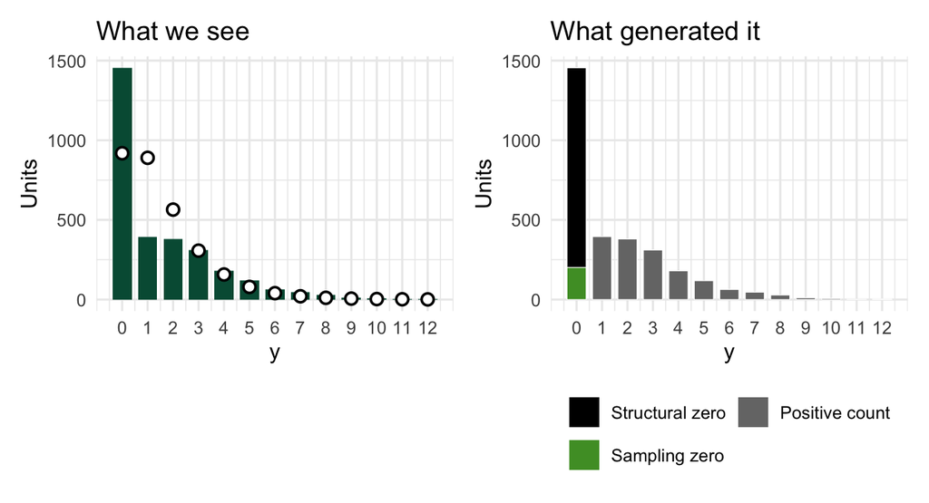

Figure 4: Simulated zero-inflated Poisson data, 3,000 units. Left: what we observe, with the frequencies a Poisson regression on x and z predicts (points). Right: the same bars, split by where each count came from.

```r
sim_freq <- sim %>% count(y) %>% filter(y <= 12) %>%
  mutate(poisson = colSums(pmat_pois(fitted(sim_p), 12))[y + 1])

p_seen <- ggplot(sim_freq, aes(x = y)) +
  geom_col(aes(y = n), fill = bu_green, width = .75) +
  geom_point(aes(y = poisson), shape = 21, fill = "white", color = bu_black, size = 2.4, stroke = 1) +
  scale_x_continuous(breaks = 0:12) +
  labs(x = "y", y = "Units", title = "What we see") +
  theme_bu()

p_truth <- sim %>% filter(y <= 12) %>%
  ggplot(aes(x = y, fill = source)) +
  geom_bar(width = .75, color = "white", linewidth = .2) +
  scale_fill_manual(values = c(bu_black, bu_lightgreen, bu_grey)) +
  scale_x_continuous(breaks = 0:12) +
  labs(x = "y", y = "Units", fill = NULL, title = "What generated it") +
  guides(fill = guide_legend(nrow = 2)) +
  theme_bu() +
  theme(legend.position = "bottom")

p_seen + p_truth
```

As analysts, we get the left panel: 1455 zeros, of which a Poisson predicts 918. The right panel is the (unknown) truth: 1254 structural zeros and 201 sampling zeros. The model’s job is to split that zero bar without seeing where the two groups fall. It can, because the two kinds of zero have different covariates behind them — structural zeros pile up where $z$ is high, sampling zeros where $x$ is low.

## One distribution, two stories

Figure 5 builds each model’s PMF from its parts, for a single unit with an at-risk rate of 2.5.

```r
lam_demo <- 2.5
zero_share <- .4
j <- 0:9

# ZIP: choose psi so the probability of a zero is 0.4
psi_demo <- (zero_share - exp(-lam_demo)) / (1 - exp(-lam_demo))

# hurdle: probability pi of clearing the hurdle, then a truncated Poisson
hurdle_pmf <- function(pi_clear) {
  bind_rows(tibble(j, part = "Did not clear hurdle", p = (1 - pi_clear) * (j == 0)),
            tibble(j, part = "From the count",
                   p = ifelse(j == 0, 0, pi_clear * dpois(j, lam_demo) / (1 - exp(-lam_demo)))))
}

pmf_parts <- bind_rows(
  `Zero-inflated Poisson, 40% zeros` =
    bind_rows(tibble(j, part = "Structural zero", p = psi_demo * (j == 0)),
              tibble(j, part = "From the count", p = (1 - psi_demo) * dpois(j, lam_demo))),
  `Hurdle Poisson, 40% zeros` = hurdle_pmf(1 - zero_share),
  `Hurdle Poisson, 3% zeros` = hurdle_pmf(.97), .id = "model") %>%
  mutate(model = fct_inorder(model),
         part = factor(part, levels = c("Structural zero", "Did not clear hurdle", "From the count")))
```

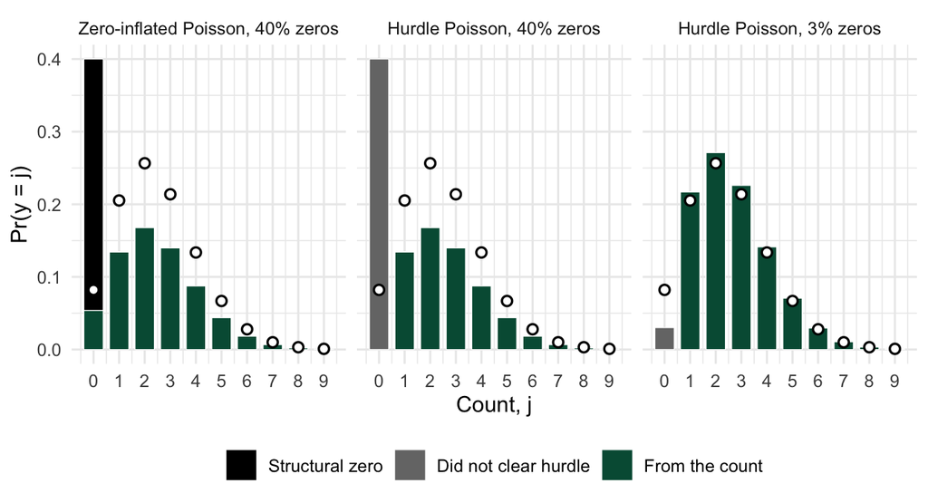

Figure 5: PMFs built from their parts, at-risk rate 2.5. Bars are colored by the part of the model that produces them; points are the Poisson with rate 2.5. Left: zero-inflated Poisson with 40% zeros. Middle: hurdle Poisson with 40% zeros. Right: hurdle Poisson with 3% zeros.

```r
ggplot(pmf_parts, aes(x = j, y = p)) +
  geom_col(aes(fill = part), width = .75, color = "white", linewidth = .2) +
  geom_point(data = tibble(j, poisson = dpois(j, lam_demo)), aes(y = poisson),
             shape = 21, fill = "white", color = bu_black, size = 2, stroke = .9) +
  facet_wrap(~ model, nrow = 1) +
  scale_fill_manual(values = c(bu_black, bu_grey, bu_green)) +
  scale_x_continuous(breaks = j) +
  labs(x = "Count, j", y = "Pr(y = j)", fill = NULL) +
  theme_bu() +
  theme(legend.position = "bottom")
```

Compare the left and middle panels. The bars are *identical*; only the colors differ. With the same at-risk rate and the same share of zeros, a zero-inflated Poisson and a hurdle Poisson are the same distribution. So for a single unit, the data can’t tell the models apart. What separates them is the story and the covariates: which variables drive the zeros, and what the binary part means. The right panel is the one thing only the hurdle can do: put *less* probability on zero than the Poisson does. A zero-inflated model can only add zeros.

# The zero-inflated Poisson

## The setup

Write the count as $y_{i} = p_{i}^{*}\, y_{i}^{*}$, where $p_{i}^{*}$ is a dichotomous variable for whether unit $i$ makes the transition into the at-risk state — the intuition of the binary models — and $y_{i}^{*}$ is the Poisson count for those who do. We never observe $p_i^*$, and we see $y_i^*$ only when $p_i^* = 1$. Each gets its own covariates and link. Let $\psi_i$ be the probability of being a structural zero (*not* making the transition):

$$\psi_i = \Lambda(z_i\gamma) = \frac{e^{z_{i}\gamma}}{1+e^{z_{i}\gamma}} \;\; (\text{or } \Phi(z_i\gamma)), \qquad P(y_{i}^{*} = j) = \frac{e^{-\lambda_i} \lambda_i^{j}}{j!}, \quad \lambda_{i} = e^{x_{i} \beta}$$

With exposure, as last week, $\lambda_i = e^{x_i\beta + \ln d_i}$, where $d_i$ is the number of years the dyad existed.

## The PMF

A zero happens two ways: the unit is a structural zero, or it’s at risk and the Poisson produces a zero. A positive count happens one way. So

$$\begin{aligned}
P(y_{i}=0 \mid x_{i}, z_i) &= \psi_{i}+(1-\psi_{i})\,e^{-\lambda_{i}} \\[8pt]
P(y_{i} = j \mid x_{i}, z_i) &= (1-\psi_{i})\,\frac{e^{-\lambda_{i}}\lambda_{i}^{j}}{j!} \qquad \text{for } j>0
\end{aligned}$$

This is the **zero-inflated Poisson (ZIP)** (Lambert 1992) — the Lambert from last week, whose manufacturing equipment was either aligned (no defects, ever) or misaligned (defects at a Poisson rate). The two lines are the left panel of Figure 5: the black and green parts of the zero bar are $\psi_i$ and $(1-\psi_i)e^{-\lambda_i}$.

## A discrete mixture: the mean and the variance

Let $s_i = 1$ if unit $i$ is at risk (probability $1 - \psi_i$). Given $s_i = 1$, $y_i$ is Poisson with mean and variance $\lambda_i$; given $s_i = 0$, it’s zero. The laws of total expectation and total variance, as last week:

$$\begin{aligned}
E[y_i] &= E\big[E[y_i \mid s_i]\big] = (1 - \psi_i)\,\lambda_i \\[6pt]
var[y_i] &= E\big[var[y_i \mid s_i]\big] + var\big[E[y_i \mid s_i]\big] \\[4pt]
&= (1 - \psi_i)\,\lambda_i + \lambda_i^2\,\psi_i(1 - \psi_i) \\[4pt]
&= (1 - \psi_i)\,\lambda_i\,(1 + \psi_i\lambda_i)
\end{aligned}$$

Two things. First, $\lambda_i$ is no longer the expected count; it’s the expected count *for an at-risk unit*. Second,

$$\frac{var[y_i]}{E[y_i]} = 1 + \psi_i\lambda_i > 1 \text{ whenever } \psi_i > 0$$

**Structural zeros produce overdispersion on their own**, even though the at-risk units are perfectly Poisson. A test for overdispersion can’t tell unobserved heterogeneity in the rate from a second regime.

Each model is an assumption about the rates of units that share the same $x$, rates we can’t see. The Poisson gives every dyad one rate. The negative binomial spreads rates along a gamma, none exactly zero — Paraguay and Mongolia get a tiny rate, not no rate. The ZIP gives two rates, zero and $\lambda$. The ZINB puts a spike at zero and spreads the rest.

## The likelihood

With $I_i = 1$ if $y_i > 0$, the zeros contribute the first line of the PMF and the positives the second:

$$\begin{aligned}
\ln L(\gamma, \beta \mid y) = {} & \sum_{i=1}^{n} (1 - I_i)\ln\Big[\psi_i + (1 - \psi_i)e^{-\lambda_i}\Big] \\[4pt]
& + \sum_{i=1}^{n} I_i\Big[\ln(1 - \psi_i) - \lambda_i + y_i\ln\lambda_i - \ln(y_i!)\Big]
\end{aligned}$$

with $\psi_i = \Lambda(z_i\gamma)$ and $\lambda_i = e^{x_i\beta + \ln d_i}$. Each positive count contributes last week’s Poisson log-likelihood plus $\ln(1-\psi_i)$. Each zero contributes the log of a *sum*, which doesn’t break apart: $\psi_i$ and $\lambda_i$ are tangled inside it, so the two equations have to be estimated together.

**Read the signs carefully**

$\psi_i$ is the probability of being a **structural zero**. A positive $\gamma_k$ makes a unit *more* likely to be an always-zero and *less* likely to be at risk — backwards from how we’d normally read a logit in a model of events. This is the default in `pscl` and Stata. A negative coefficient in the inflation equation means the variable makes events *possible*.

The zeros’ contributions to the score have both $\psi_i$ and $\lambda_i$ in them, so the Hessian’s cross-partials aren’t zero: the estimates of $\gamma$ and $\beta$ are correlated, another way of saying the two equations can’t be estimated apart.

## Estimating the ZIP

`pscl::zeroinfl()` estimates it. The formula takes the count equation, then `|`, then the inflation equation.

### Recovering a known truth

```r
zip_sim <- zeroinfl(y ~ x | z, data = sim, dist = "poisson")
b_sim <- coef(zip_sim, "count")
g_sim <- coef(zip_sim, "zero")
```

On the simulated data the estimates come back close to the truth: $\widehat\beta$ = (0.82, 0.49) against (0.8, 0.5), and $\widehat\gamma$ = (-0.54, 1.26) against (-0.5, 1.2). The estimated number of structural zeros, $\sum_i \widehat\psi_i$ = 1223, is close to the true 1254. The model split the zero bar without seeing the colors.

### Disputes

```r
# the two equations' design matrices, used below for predictions
X <- model.matrix(~ demmin + lcapratio + contig + lcapdist + major, dy)
Z <- model.matrix(~ lcapdist + major, dy)
kx <- ncol(X)
kz <- ncol(Z)

dy_zf <- mids ~ demmin + lcapratio + contig + lcapdist + major + offset(lyears) | lcapdist + major
zip_pscl <- zeroinfl(dy_zf, data = dy, dist = "poisson")

tibble(Equation = rep(c("Count", "Inflation"), c(kx, kz)),
       Variable = c(dy_labels[colnames(X)], dy_labels[colnames(Z)]),
       Estimate = c(coef(zip_pscl, "count"), coef(zip_pscl, "zero")),
       `s.e.` = sqrt(diag(vcov(zip_pscl)))) %>%
  kbl(digits = 4) %>%
  kable_styling(full_width = FALSE)
```

Table 1: ZIP of MIDs per dyad, pscl::zeroinfl().

| Equation | Variable | Estimate | s.e. |
| --- | --- | --- | --- |
| Count | Constant | -4.6132 | 0.4212 |
| Count | Democracy (lower Polity score) | -0.0717 | 0.0136 |
| Count | ln(capability ratio) | -0.1920 | 0.0288 |
| Count | Contiguous | 1.6436 | 0.1058 |
| Count | ln(capital distance) | 0.0661 | 0.0497 |
| Count | Major power in dyad | 0.7933 | 0.1120 |
| Inflation | Constant | -7.7094 | 0.7460 |
| Inflation | ln(capital distance) | 1.2733 | 0.0968 |
| Inflation | Major power in dyad | -2.5969 | 0.2292 |

The ZIP’s log-likelihood (-1800.8) is far better than the Poisson’s (-2238.4) and far worse than the negative binomial’s (-1614.7): structural zeros explain some of the overdispersion, not most. Even dyads with opportunity vary more in their rates than a Poisson allows. We need both kinds of mixture.

## The zero-inflated negative binomial

Swap the Poisson in the at-risk regime for the negative binomial, whose probability of a zero is $(1 + \alpha\lambda_i)^{-1/\alpha}$:

$$\begin{aligned}
\ln L(\gamma, \beta, \alpha \mid y) = {} & \sum_{i=1}^{n} (1 - I_i)\ln\Big[\psi_i + (1 - \psi_i)(1 + \alpha\lambda_i)^{-1/\alpha}\Big] \\[4pt]
& + \sum_{i=1}^{n} I_i\Big[\ln(1 - \psi_i) + \ln f_{NB}(y_i \mid \lambda_i, \alpha)\Big]
\end{aligned}$$

where, as last week,

$$\begin{aligned}
\ln f_{NB}(y_i \mid \lambda_i, \alpha) = {} & \ln\Gamma(y_i + \alpha^{-1}) - \ln\Gamma(\alpha^{-1}) - \ln(y_i!) \\[4pt]
& + y_i\ln\alpha + y_i\ln\lambda_i - (y_i + \alpha^{-1})\ln(1 + \alpha\lambda_i)
\end{aligned}$$

The mean is still $(1-\psi_i)\lambda_i$; the variance, $(1-\psi_i)\lambda_i(1 + \alpha\lambda_i + \psi_i\lambda_i)$, carries both sources of overdispersion. `pscl` estimates $\ln\theta$, with $\theta = 1/\alpha$, so the dispersion stays positive.

```r
zinb_pscl <- zeroinfl(dy_zf, data = dy, dist = "negbin")

# estimates and covariance matrix for the simulations below. pscl's parameters
# are (beta, gamma, ln theta); ln alpha = -ln theta, so the last row and column
# of the covariance matrix change sign
b_zinb <- coef(zinb_pscl, "count")
g_zinb <- coef(zinb_pscl, "zero")
alpha_zinb <- 1 / zinb_pscl$theta
zinb_par <- c(b_zinb, g_zinb, log(alpha_zinb))
J <- diag(c(rep(1, kx + kz), -1))
V_zinb <- J %*% solve(-zinb_pscl$optim$hessian) %*% J
```

The ZINB’s log-likelihood is 28.0 better than the negative binomial’s, for 3 more parameters. And $\widehat\alpha$ falls from 4.80 to 3.19: part of what the negative binomial treated as extra-Poisson noise is now measured, as opportunity.

# The hurdle model

The hurdle model (Mullahy 1986; Zorn 1998) keeps the two parts apart. Its standard motivation comes from health economics, in doctor visits: the patient decides whether to see a doctor at all, and once the patient makes contact, the physician largely decides how many visits follow (Pohlmeier and Ulrich 1995). Two decision-makers, two processes, and a zero means only that the patient never made contact. With $\pi_i$ the probability of clearing the hurdle and a Poisson count:

$$f(y_i \mid \pi_i, \lambda_i) =
\begin{cases}
1 - \pi_i & \text{if } y_i = 0 \\[8pt]
\pi_i \, \dfrac{e^{-\lambda_i}\lambda_i^{y_i} / y_i!}{1 - e^{-\lambda_i}} & \text{if } y_i > 0
\end{cases}$$

Every zero comes from failing to clear the hurdle. The count is a Poisson **truncated** at zero — divided by $1 - e^{-\lambda_i}$ so its probabilities over $1, 2, 3, \ldots$ sum to one. Those are the middle and right panels of Figure 5. The expected count is $E[y_i] = \pi_i\,\lambda_i/(1 - e^{-\lambda_i})$, and the log-likelihood is

$$\begin{aligned}
\ln L(\gamma, \beta \mid y) = {} & \underbrace{\sum_{i=1}^{n} \Big[ (1 - I_i)\ln(1 - \pi_i) + I_i \ln \pi_i \Big]}_{\text{the hurdle: a binary model}} \\[6pt]
& + \underbrace{\sum_{i=1}^{n} I_i \Big[ y_i\ln\lambda_i - \lambda_i - \ln(y_i!) - \ln\big(1 - e^{-\lambda_i}\big) \Big]}_{\text{the count, given } y_i > 0}
\end{aligned}$$

**Nothing is shared between the two sums.** $\gamma$ (in $\pi_i$) appears only in the first and $\beta$ only in the second, so the hurdle’s likelihood separates: estimate a binary model on everything and a truncated count on the positives, separately. The ZIP’s doesn’t.

## The Poisson is a hurdle model with its hands tied

Under the Poisson, $Pr(y_i > 0) = 1 - e^{-\lambda_i} = 1 - \exp(-e^{x_i\beta + \ln d_i})$. That’s the complementary log-log from last week and Week 4, with the exposure as an offset. And given $y_i > 0$, the Poisson is the truncated Poisson with the same $\lambda_i$. So the Poisson *is* a hurdle model: cloglog hurdle, truncated Poisson count, one $\beta$ for both. Give the cloglog its own $\gamma$ and the Poisson becomes the special case $\gamma = \beta$ — $k$ restrictions, testable with a likelihood ratio test.

```r
# the hurdle: cloglog of any MIDs, all dyads, exposure as an offset
dy_cl <- glm(I(mids > 0) ~ demmin + lcapratio + contig + lcapdist + major + offset(lyears),
             data = dy, family = binomial(link = "cloglog"))

# the whole hurdle from pscl: zero.dist = "poisson" makes the binary part a
# cloglog, and the count part is a zero-truncated Poisson. Its binary part
# matches dy_cl, because the likelihood separates
hp_cl_pscl <- hurdle(dy_f, data = dy, dist = "poisson", zero.dist = "poisson")
tp_b  <- coef(hp_cl_pscl, "count")
tp_se <- sqrt(diag(vcov(hp_cl_pscl)))[paste0("count_", names(tp_b))]

lr_hurdle <- 2 * (as.numeric(logLik(hp_cl_pscl)) - as.numeric(logLik(dy_p)))

tibble(Model = c("Poisson", "Hurdle: cloglog + truncated Poisson"),
       `ln L` = c(as.numeric(logLik(dy_p)), as.numeric(logLik(hp_cl_pscl))),
       Parameters = c(kx, 2 * kx)) %>%
  kbl(digits = 2) %>%
  kable_styling(full_width = FALSE)
```

Table 2: The Poisson against the hurdle model it is a special case of: log-likelihoods and the likelihood ratio test of gamma = beta.

| Model | ln L | Parameters |
| --- | --- | --- |
| Poisson | -2238.43 | 6 |
| Hurdle: cloglog + truncated Poisson | -1740.02 | 12 |

The likelihood ratio statistic is 996.8 on 6 degrees of freedom. Whether a dyad has any disputes and how many it has are not governed by the same coefficients. Figure 6 shows how.

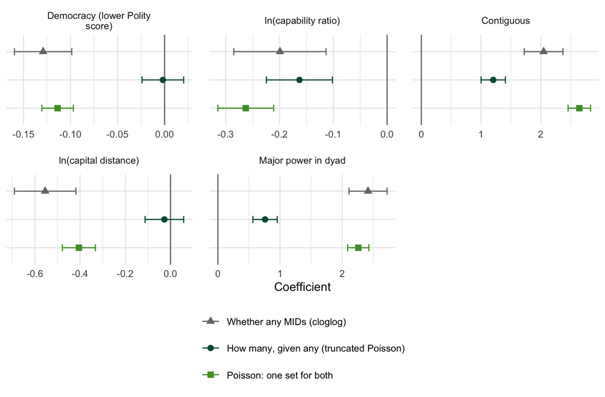

Figure 6: Coefficients and 95% intervals from the two parts of the hurdle model and from the Poisson, which forces them to be equal. Each panel has its own scale.

```r
parts <- c("Whether any MIDs (cloglog)", "How many, given any (truncated Poisson)", "Poisson: one set for both")

coefs3 <- bind_rows(
  tibble(term = names(coef(dy_cl)), est = coef(dy_cl), se = sqrt(diag(vcov(dy_cl))), part = parts[1]),
  tibble(term = names(tp_b), est = tp_b, se = tp_se, part = parts[2]),
  tibble(term = names(coef(dy_p)), est = coef(dy_p), se = sqrt(diag(vcov(dy_p))), part = parts[3])) %>%
  filter(term != "(Intercept)") %>%
  mutate(term = factor(dy_labels[term], levels = dy_labels),
         part = factor(part, levels = rev(parts)))

ggplot(coefs3, aes(x = est, y = part, color = part, shape = part)) +
  geom_vline(xintercept = 0, color = bu_grey) +
  geom_errorbar(aes(xmin = est - 1.96 * se, xmax = est + 1.96 * se), width = .25, orientation = "y") +
  geom_point(size = 2.2) +
  facet_wrap(~ term, scales = "free_x", ncol = 3, labeller = label_wrap_gen(28)) +
  scale_color_manual(values = c(bu_grey, bu_green, bu_lightgreen), breaks = parts) +
  scale_shape_manual(values = c(17, 16, 15), breaks = parts) +
  labs(x = "Coefficient", y = NULL, color = NULL, shape = NULL) +
  guides(color = guide_legend(ncol = 1), shape = guide_legend(ncol = 1)) +
  theme_bu(base_size = 10) +
  theme(axis.text.y = element_blank(), legend.position = "bottom", panel.spacing.x = unit(1, "lines"))
```

**Democracy** is the striking row. It lowers the chance that a dyad has *any* dispute (-0.129), and has nothing to do with how many disputes a dyad has once it has one (-0.002). The democratic peace, in these data, is about whether pairs of states fight at all. **Distance** works the same way: it governs whether (-0.555), not how many (-0.027). The Poisson’s single coefficient on each blends the two and would have us conclude democracy and distance shape both. One coefficient asked to describe two processes describes neither — the lesson of competing risks in Week 5.

## The logit hurdle

In practice the hurdle is usually a logit, and then the Poisson isn’t a special case. The likelihood still separates, so the hurdle part is an ordinary logit of “any MIDs” that could be estimated on its own. Below we fit two logit hurdles, one with a truncated Poisson count and one with a truncated negative binomial, and compare them with the zero-inflated models.

```r
# logit hurdles: a logit for any MIDs, a truncated NB (or Poisson) for how many,
# the full set of covariates in both parts; pscl applies the exposure offset to both
hnb_pscl <- hurdle(dy_f, data = dy, dist = "negbin")
hp_pscl  <- hurdle(dy_f, data = dy, dist = "poisson")
```

# Zero-inflated or hurdle?

Zero-inflated and hurdle models compared

|  | Zero-inflated | Hurdle |
| --- | --- | --- |
| Where zeros come from | Both parts: structural zeros from the binary part, sampling zeros from the count | The binary part only |
| What the binary part models | $\psi$, the probability of being a structural zero — never at risk | $\pi$, the probability of clearing the hurdle — any events |
| The count part | Poisson or NB, over $0, 1, 2, \ldots$ | Poisson or NB truncated at zero, over $1, 2, \ldots$ |
| Fewer zeros than the count distribution implies? | No — it can only add zeros | Yes |
| The likelihood | Doesn’t separate; estimate both parts together | Separates; the parts can be estimated one at a time |
| Is the Poisson a special case? | Only at $\psi = 0$, the edge of the parameter space | Yes, with a cloglog hurdle and $\gamma = \beta$ |

Figure 5 showed that the data alone often can’t choose. The theory has to, and the question is: **can a unit that is at risk still have a zero?** Opportunity and willingness says yes — a dyad with opportunity may never be willing — so it’s a zero-inflated story. A hurdle story says crossing the threshold means at least one event. And the two binary parts answer different questions: *which dyads lack the opportunity to fight?* versus *which dyads have any disputes?* Their coefficients aren’t estimates of the same thing.

# Back to the dyads

## The estimates

```r
# the same label for a variable in the NB, in the count part ("count_"), and in
# the binary part ("zero_") of the two-part models
three_map <- c(setNames(dy_labels, names(dy_labels)),
               setNames(dy_labels, paste0("count_", names(dy_labels))),
               setNames(paste("Binary:", dy_labels), paste0("zero_", names(dy_labels))))
three_map <- three_map[!duplicated(names(three_map))]
three_map <- three_map[order(grepl("^zero_", names(three_map)))]

extra_rows <- data.frame(term = c("ln L", "alpha"),
                         NB = sprintf("%.1f", c(logLik(dy_nb), alpha_dy)),
                         ZINB = sprintf("%.1f", c(logLik(zinb_pscl), 0)),
                         `Hurdle NB` = sprintf("%.1f", c(logLik(hnb_pscl), 0)),
                         check.names = FALSE)
extra_rows[2, 2:4] <- sprintf("%.3f", c(alpha_dy, 1 / zinb_pscl$theta, 1 / hnb_pscl$theta))

modelsummary(list("NB" = dy_nb, "ZINB" = zinb_pscl, "Hurdle NB" = hnb_pscl),
             coef_map = three_map, stars = TRUE,
             gof_map = c("nobs", "aic", "bic"), add_rows = extra_rows,
             title = "MID onsets per dyad, 1951-1985: negative binomial, zero-inflated negative binomial, and hurdle negative binomial. All three use years in the system as exposure.",
             notes = c("Rows labeled Binary are the binary part of each two-part model. For the ZINB, it is a logit of the probability of a structural zero (no opportunity); for the hurdle, a logit of the probability of any MIDs. Their signs run in opposite directions.",
                       "alpha is the negative binomial dispersion parameter; pscl estimates theta = 1/alpha."))
```

Table 3

MID onsets per dyad, 1951-1985: negative binomial, zero-inflated negative binomial, and hurdle negative binomial. All three use years in the system as exposure.

|  | NB | ZINB | Hurdle NB |
| --- | --- | --- | --- |
| Democracy (lower Polity score) | -0.087*** | -0.082*** | 0.007 |
|  | (0.015) | (0.016) | (0.033) |
| ln(capability ratio) | -0.263*** | -0.253*** | -0.141+ |
|  | (0.047) | (0.046) | (0.076) |
| Contiguous | 3.113*** | 2.832*** | 1.779*** |
|  | (0.201) | (0.207) | (0.292) |
| ln(capital distance) | -0.611*** | -0.013 | -0.104 |
|  | (0.082) | (0.099) | (0.119) |
| Major power in dyad | 3.494*** | 1.997*** | 1.350*** |
|  | (0.180) | (0.256) | (0.293) |
| Constant | -2.287*** | -5.850*** | -4.122*** |
|  | (0.693) | (0.744) | (1.104) |
| Binary: Democracy (lower Polity score) |  |  | -0.133*** |
|  |  |  | (0.018) |
| Binary: ln(capability ratio) |  |  | -0.246*** |
|  |  |  | (0.049) |
| Binary: Contiguous |  |  | 2.630*** |
|  |  |  | (0.203) |
| Binary: ln(capital distance) |  | 1.816*** | -0.578*** |
|  |  | (0.213) | (0.084) |
| Binary: Major power in dyad |  | -3.559*** | 3.040*** |
|  |  | (0.766) | (0.186) |
| Binary: Constant |  | -14.286*** | -3.062*** |
|  |  | (1.861) | (0.711) |
| Num.Obs. | 10432 | 10432 | 10432 |
| AIC | 3243.4 | 3193.3 | 3173.7 |
| BIC | 3294.2 | 3265.9 | 3268.0 |
| ln L | -1614.7 | -1586.7 | -1573.8 |
| alpha | 4.802 | 3.191 | 4.051 |

+ p < 0.1, * p < 0.05, ** p < 0.01, *** p < 0.001  
Rows labeled Binary are the binary part of each two-part model. For the ZINB, it is a logit of the probability of a structural zero (no opportunity); for the hurdle, a logit of the probability of any MIDs. Their signs run in opposite directions.  
alpha is the negative binomial dispersion parameter; pscl estimates theta = 1/alpha.

Figure 7 puts the coefficients on distance, major-power status, and democracy side by side across the negative binomial, the two equations of the ZINB, and the two parts of the hurdle negative binomial. Color marks the model; shape marks the count equation (circles) or the binary one (triangles).

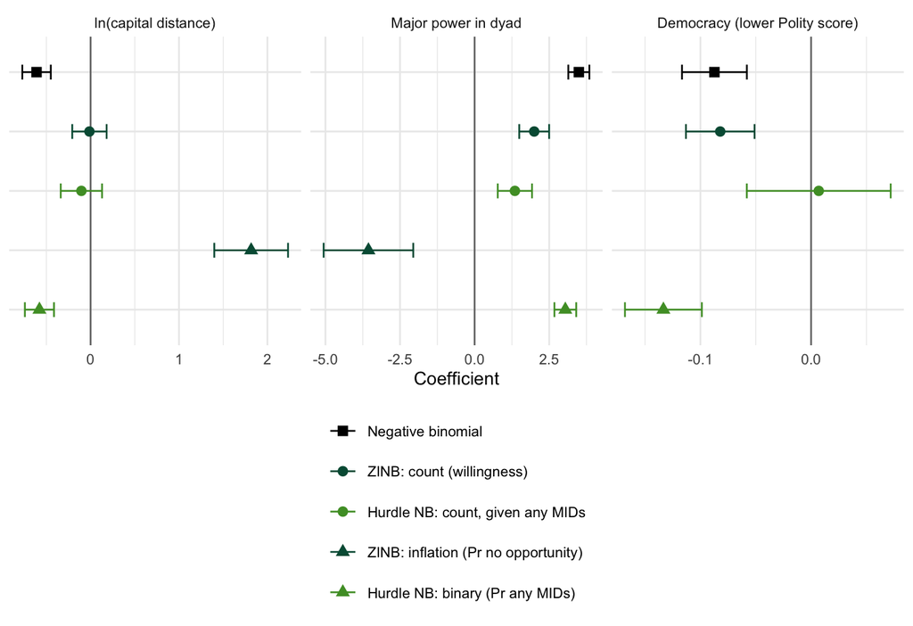

Figure 7: Coefficients and 95% intervals for distance, major-power status, and democracy: the negative binomial, the ZINB’s count (willingness) and inflation (no opportunity) equations, and the hurdle negative binomial’s count and binary (any MIDs) parts. The two binary equations model different events, so their signs run in opposite directions. Democracy is not in the ZINB’s inflation equation.

```r
se_zinb <- sqrt(diag(V_zinb))
se_hnb <- sqrt(diag(vcov(hnb_pscl)))
eqs <- c("Negative binomial",
         "ZINB: count (willingness)", "Hurdle NB: count, given any MIDs",
         "ZINB: inflation (Pr no opportunity)", "Hurdle NB: binary (Pr any MIDs)")

migrate <- bind_rows(
  tibble(term = names(coef(dy_nb)), est = coef(dy_nb), se = sqrt(diag(vcov(dy_nb))), eq = eqs[1]),
  tibble(term = colnames(X), est = b_zinb, se = se_zinb[1:kx], eq = eqs[2]),
  tibble(term = names(coef(hnb_pscl, "count")), est = coef(hnb_pscl, "count"),
         se = se_hnb[paste0("count_", names(coef(hnb_pscl, "count")))], eq = eqs[3]),
  tibble(term = colnames(Z), est = g_zinb, se = se_zinb[kx + 1:kz], eq = eqs[4]),
  tibble(term = names(coef(hnb_pscl, "zero")), est = coef(hnb_pscl, "zero"),
         se = se_hnb[paste0("zero_", names(coef(hnb_pscl, "zero")))], eq = eqs[5])) %>%
  filter(term %in% c("lcapdist", "major", "demmin")) %>%
  mutate(term = factor(dy_labels[term], levels = dy_labels[c("lcapdist", "major", "demmin")]),
         eq = factor(eq, levels = rev(eqs)))

# color is the model, shape is the equation: count (circle) or binary (triangle)
ggplot(migrate, aes(x = est, y = eq, color = eq, shape = eq)) +
  geom_vline(xintercept = 0, color = bu_grey) +
  geom_errorbar(aes(xmin = est - 1.96 * se, xmax = est + 1.96 * se), width = .25, orientation = "y") +
  geom_point(size = 2.4) +
  facet_wrap(~ term, scales = "free_x") +
  scale_color_manual(values = c(bu_black, bu_green, bu_lightgreen, bu_green, bu_lightgreen), breaks = eqs) +
  scale_shape_manual(values = c(15, 16, 16, 17, 17), breaks = eqs) +
  labs(x = "Coefficient", y = NULL, color = NULL, shape = NULL) +
  guides(color = guide_legend(ncol = 1), shape = guide_legend(ncol = 1)) +
  theme_bu(base_size = 10) +
  theme(axis.text.y = element_blank(), legend.position = "bottom")
```

In the negative binomial, distance lowers the rate of disputes (-0.61). In the ZINB, that effect moves into the inflation equation (1.82: distant dyads are much more likely to lack opportunity) and out of the count equation (-0.01). The hurdle agrees: distance lowers the chance of any MIDs (-0.58) and does little to how many (-0.10). Major-power status works through both equations in both models.

Notice that distance’s two binary coefficients have opposite signs. They aren’t estimates of the same thing. The ZINB’s inflation equation models the probability of a **structural zero** — no opportunity — and that’s latent: we never see which dyads lacked it. The hurdle’s binary part models the probability of **any MIDs**, which we do see, and which takes both opportunity and willingness. Same substantive story, farther means fewer disputes; different quantities, so different signs and sizes.

Democracy shows why that matters. The ZINB puts the democratic peace in willingness: democracy lowers the rate among dyads with opportunity (-0.082, nearly the negative binomial’s -0.087). The hurdle puts it in whether a dyad has any dispute (-0.133) and not in how many (0.007), as the cloglog hurdle did in Figure 6. Each answer is partly built in. The ZINB keeps democracy out of the opportunity equation by assumption, so its effect can only appear as willingness. The hurdle’s binary part blends opportunity and willingness, so a willingness effect that keeps dyads from ever fighting appears as “any MIDs.” The data don’t choose between these; the theory has to say which structure the democratic peace has.

## Choosing among the models

```r
fit_row <- function(m, name) {
  tibble(Model = name, Parameters = attr(logLik(m), "df"), `ln L` = as.numeric(logLik(m)),
         AIC = AIC(m), BIC = BIC(m))
}

bind_rows(fit_row(dy_p, "Poisson"), fit_row(dy_nb, "Negative binomial"),
          fit_row(zip_pscl, "Zero-inflated Poisson"), fit_row(zinb_pscl, "Zero-inflated NB"),
          fit_row(hp_pscl, "Hurdle Poisson"), fit_row(hnb_pscl, "Hurdle NB")) %>%
  kbl(digits = 1) %>%
  kable_styling(full_width = FALSE)
```

Table 4: Fit of six count models of MIDs per dyad. Zero-inflated models: distance and major power in the inflation equation. Hurdle models: a logit hurdle with the full set of covariates.

| Model | Parameters | ln L | AIC | BIC |
| --- | --- | --- | --- | --- |
| Poisson | 6 | -2238.4 | 4488.9 | 4532.4 |
| Negative binomial | 7 | -1614.7 | 3243.4 | 3294.2 |
| Zero-inflated Poisson | 9 | -1800.8 | 3619.6 | 3684.9 |
| Zero-inflated NB | 10 | -1586.7 | 3193.3 | 3265.9 |
| Hurdle Poisson | 12 | -1720.6 | 3465.3 | 3552.3 |
| Hurdle NB | 13 | -1573.8 | 3173.7 | 3268.0 |

The ZINB is 50.1 AIC points and 28.3 BIC points better than the negative binomial. We can’t *test* the ZINB against the negative binomial with a likelihood ratio test, because the negative binomial is the ZINB with the inflation constant at $-\infty$, the edge of the parameter space. Published work often uses the **Vuong test** (Vuong 1989) here, but Wilson (2015) shows that’s a misuse: the Vuong test is for non-nested models, and these are nested. Fit statistics and theory have to carry the choice.

# Quantities of interest

- $\psi_i = \Lambda(z_i\gamma)$ — the probability of being a **structural zero**; $1 - \psi_i$ is the probability of **opportunity**.
- $\lambda_i = e^{x_i\beta + \ln d_i}$ — the **expected count for a dyad with opportunity**.
- $E[y_i] = (1 - \psi_i)\lambda_i$ — the **expected count**, over both regimes.
- $Pr(y_i = 0) = \psi_i + (1 - \psi_i)f(0 \mid \lambda_i)$ — structural plus sampling zeros.

## A variable in both equations

Distance is in both equations. Differentiating $E[y_i] = (1 - \psi_i)\lambda_i$:

$$\begin{aligned}
\frac{\partial E[y_i]}{\partial x_k} &= (1 - \psi_i)\lambda_i\beta_k - \lambda_i\psi_i(1 - \psi_i)\gamma_k \\[6pt]
&= E[y_i]\,\big(\beta_k - \psi_i\gamma_k\big)
\end{aligned}$$

Two channels: $\beta_k$, how many disputes a dyad with opportunity has, and $-\psi_i\gamma_k$, whether it has opportunity at all. The second is weighted by $\psi_i$, so its size depends on where the dyad is — like compression in interactions. No single coefficient is the effect.

## Simulating the quantities

The endpoint transformation needs one linear predictor; $E[y_i] = (1 - \Lambda(z_i\gamma))\,e^{x_i\beta + \ln d_i}$ has two. So simulate: draw $\beta$, $\gamma$, and $\ln\alpha$ together from their estimated sampling distribution — the draws carry the correlation between $\gamma$ and $\beta$ — compute the quantity for each draw, and take quantiles. Figure 8 takes a non-contiguous dyad with no major power, democracy and capability ratio at their medians, over the full 35 years, and varies the distance between capitals.

```r
med <- function(v) median(dy[[v]])
dist_km <- exp(seq(log(500), log(15000), length.out = 60))
off35 <- log(35)

# covariate rows in the order of the count and inflation equations: not
# contiguous, no major power, democracy and capability ratio at their medians
Xg <- cbind(1, med("demmin"), med("lcapratio"), 0, log(dist_km + 1), 0)
Zg <- cbind(1, log(dist_km + 1), 0)

# the ZINB quantities, one column per parameter vector
zinb_q <- function(B, G, A, Xm = Xg, Zm = Zg) {
  lambda <- exp(Xm %*% t(B) + off35)
  psi <- plogis(Zm %*% t(G))
  f0 <- (1 + rep(A, each = nrow(Xm)) * lambda)^(-1 / rep(A, each = nrow(Xm)))
  list(psi = psi, opportunity = 1 - psi, lambda = lambda, ey = (1 - psi) * lambda,
       sampling0 = (1 - psi) * f0, any = 1 - psi - (1 - psi) * f0)
}

# the hurdle NB's probability of a zero at the same covariate values, from its
# logit part
hurdle_p0 <- 1 - plogis(as.vector(Xg %*% coef(hnb_pscl, "zero") + off35))

draws <- mvrnorm(1000, zinb_par, V_zinb)
q_sim <- zinb_q(draws[, 1:kx], draws[, kx + 1:kz], exp(draws[, kx + kz + 1]))
q_est <- zinb_q(t(b_zinb), t(g_zinb), alpha_zinb)

summ <- function(q, name) {
  tibble(km = dist_km, quantity = name, est = as.vector(q_est[[q]]),
         lb = apply(q_sim[[q]], 1, quantile, .025), ub = apply(q_sim[[q]], 1, quantile, .975))
}

qi_dist <- bind_rows(summ("opportunity", "Pr(opportunity)"),
                     summ("lambda", "E[MIDs | opportunity]"),
                     summ("ey", "E[MIDs]")) %>%
  mutate(quantity = factor(quantity, levels = c("Pr(opportunity)", "E[MIDs | opportunity]", "E[MIDs]")))

# the negative binomial's expected count at the same values, endpoint transformation
nb_link <- as.vector(Xg %*% coef(dy_nb) + off35)
nb_se <- sqrt(diag(Xg %*% vcov(dy_nb) %*% t(Xg)))
nb_dist <- tibble(km = dist_km, quantity = factor("E[MIDs]", levels = levels(qi_dist$quantity)),
                  est = exp(nb_link), lb = exp(nb_link - 1.96 * nb_se), ub = exp(nb_link + 1.96 * nb_se))

qa <- function(q, km) { i <- which.min(abs(dist_km - km)); qi_dist$est[qi_dist$quantity == q][i] }
```

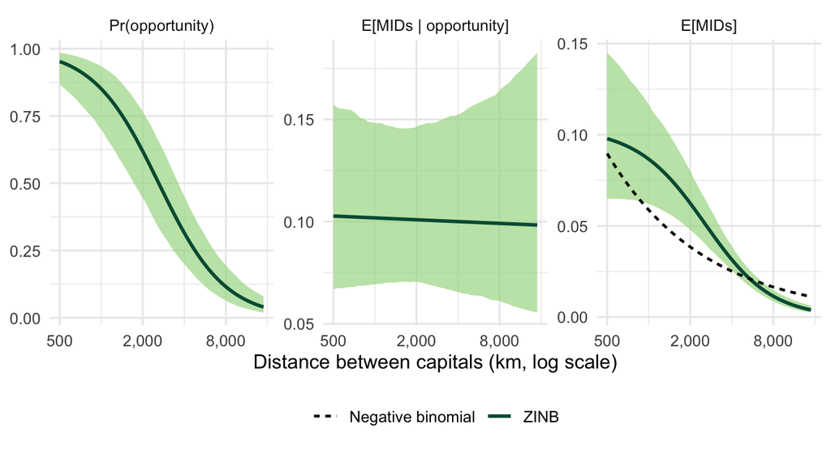

Figure 8: ZINB quantities across the distance between capitals, for a non-contiguous dyad with no major power, democracy and capability ratio at their medians, over 35 years. 95% simulation intervals. Right panel: the ZINB’s expected count (solid) and the negative binomial’s (dashed). Distance on a log scale.

```r
ggplot(qi_dist, aes(x = km, y = est)) +
  geom_ribbon(aes(ymin = lb, ymax = ub), fill = bu_palegreen, alpha = .7) +
  geom_line(aes(color = "ZINB", linetype = "ZINB"), linewidth = 1) +
  geom_line(data = nb_dist, aes(color = "Negative binomial", linetype = "Negative binomial"), linewidth = .8) +
  facet_wrap(~ quantity, scales = "free_y") +
  scale_color_manual(values = c("ZINB" = bu_green, "Negative binomial" = bu_black)) +
  scale_linetype_manual(values = c("ZINB" = "solid", "Negative binomial" = "22")) +
  scale_x_log10(breaks = c(500, 2000, 8000), labels = scales::comma) +
  labs(x = "Distance between capitals (km, log scale)", y = NULL, color = NULL, linetype = NULL) +
  theme_bu() +
  theme(legend.position = "bottom")
```

The left panel does the work: the probability of opportunity falls from 0.95 for capitals 500 km apart to 0.62 at 2,000 km and 0.117 at 8,000. A dyad that does have opportunity expects about the same number of disputes near or far (middle panel). The expected count (right) is the left panel scaled by the middle one — mostly a picture of opportunity.

## Where the zeros come from

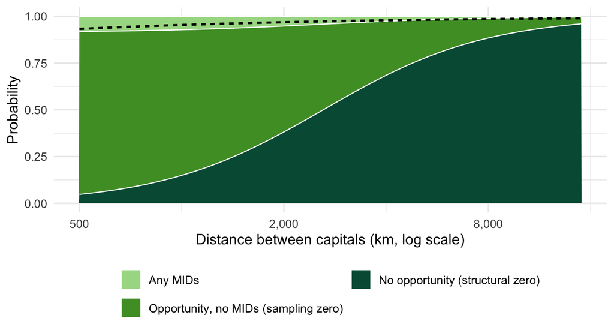

Figure 9: The probability of a structural zero (no opportunity), of a sampling zero (opportunity but no MIDs), and of any MIDs, across capital distance, from the ZINB, with the hurdle NB’s probability of a zero (dashed). Same dyad as above. Distance on a log scale.

```r
tibble(km = dist_km,
       `No opportunity (structural zero)` = as.vector(q_est$psi),
       `Opportunity, no MIDs (sampling zero)` = as.vector(q_est$sampling0),
       `Any MIDs` = as.vector(q_est$any)) %>%
  pivot_longer(-km, names_to = "outcome", values_to = "p") %>%
  mutate(outcome = factor(outcome, levels = c("Any MIDs", "Opportunity, no MIDs (sampling zero)",
                                              "No opportunity (structural zero)"))) %>%
  ggplot(aes(x = km, y = p)) +
  geom_area(aes(fill = outcome), color = "white", linewidth = .4) +
  geom_line(data = tibble(km = dist_km, p = hurdle_p0), color = bu_black, linetype = "22", linewidth = .9) +
  scale_fill_manual(values = c(bu_palegreen, bu_lightgreen, bu_green)) +
  scale_x_log10(breaks = c(500, 2000, 8000), labels = scales::comma) +
  labs(x = "Distance between capitals (km, log scale)", y = "Probability", fill = NULL) +
  theme_bu() +
  theme(legend.position = "bottom") +
  guides(fill = guide_legend(nrow = 2))
```

Near dyads mostly have opportunity, and their zeros are sampling zeros: they could have fought and didn’t. With distance, nearly every zero becomes structural. The hurdle’s probability of a zero (dashed) runs just above the ZINB’s two zero bands combined, but it’s a single band: it can’t say which kind of zero it is.

## Democracy, near and far

Democracy is only in the count equation, so its effect on the expected count is scaled by the probability of opportunity. Figure 10 shows it for two dyads that differ only in distance.

```r
dem_grid <- seq(-10, 10, by = .5)
dem_q <- map_dfr(c(800, 2500), function(km) {
  Xd <- cbind(1, dem_grid, med("lcapratio"), 0, log(km + 1), 0)
  Zd <- cbind(1, log(km + 1), 0)[rep(1, length(dem_grid)), , drop = FALSE]
  sim_ey <- zinb_q(draws[, 1:kx], draws[, kx + 1:kz], exp(draws[, kx + kz + 1]), Xd, Zd)$ey
  tibble(demmin = dem_grid, dyad = sprintf("Capitals %s km apart", scales::comma(km)),
         est = as.vector(zinb_q(t(b_zinb), t(g_zinb), alpha_zinb, Xd, Zd)$ey),
         lb = apply(sim_ey, 1, quantile, .025), ub = apply(sim_ey, 1, quantile, .975))
})
```

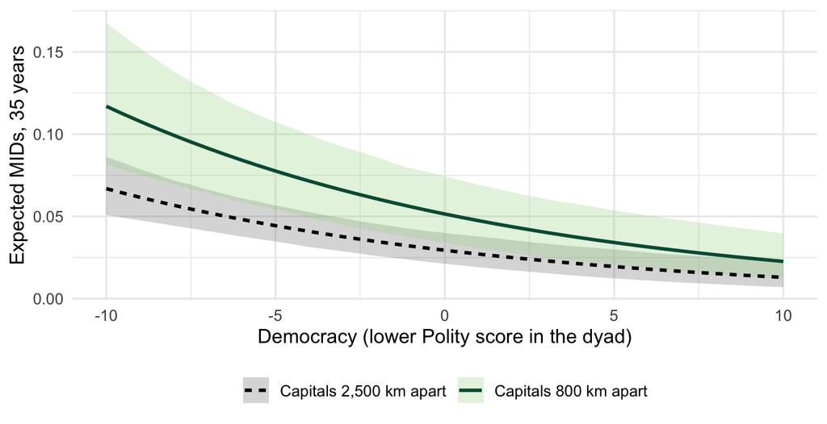

Figure 10: Expected MIDs over 35 years across the lower Polity score in the dyad, ZINB, for two non-contiguous, non-major-power dyads that differ only in capital distance. 95% simulation intervals.

```r
ggplot(dem_q, aes(x = demmin, y = est, color = dyad, fill = dyad, linetype = dyad)) +
  geom_ribbon(aes(ymin = lb, ymax = ub), alpha = .3, color = NA) +
  geom_line(linewidth = 1) +
  scale_color_manual(values = c(bu_black, bu_green)) +
  scale_fill_manual(values = c(bu_greyfill, bu_palegreen)) +
  scale_linetype_manual(values = c("22", "solid")) +
  labs(x = "Democracy (lower Polity score in the dyad)", y = "Expected MIDs, 35 years",
       color = NULL, fill = NULL, linetype = NULL) +
  theme_bu() +
  theme(legend.position = "bottom")
```

In the ZINB, the democratic peace is a willingness effect, and willingness only matters where there’s opportunity. For the near dyad, moving from two autocracies to two democracies cuts expected disputes from 0.12 to 0.02. For the far dyad, there’s less to cut, because it’s less likely to have the opportunity in the first place.

# Which dyads have opportunity?

For a dyad with no MIDs, Bayes’ rule gives the probability that it’s a structural zero — that it never had the opportunity:

$$Pr(\text{structural} \mid y_i = 0) = \frac{\psi_i}{\psi_i + (1 - \psi_i)f(0 \mid \lambda_i)}$$

A dyad with any MID had opportunity, so its probability is zero. The estimated probability of opportunity, $1 - \psi_i$, is the model’s answer to the question the politically relevant dyads rule answers by hand. Figure 11 compares them.

```r
lambda_zinb <- as.vector(exp(X %*% b_zinb + dy$lyears))
psi_zinb    <- as.vector(plogis(Z %*% g_zinb))
f0_zinb     <- (1 + alpha_zinb * lambda_zinb)^(-1 / alpha_zinb)

dy_post <- dy %>%
  mutate(opportunity = 1 - psi_zinb,
         post_structural = if_else(mids == 0, psi_zinb / (psi_zinb + (1 - psi_zinb) * f0_zinb), 0),
         rule = if_else(relevant == 1, "Politically relevant", "Not relevant"),
         dyad_type = factor(case_when(major == 1 ~ "Includes a major power",
                                      contig == 1 ~ "Contiguous, no major power",
                                      TRUE ~ "Neither"),
                            levels = c("Includes a major power", "Contiguous, no major power", "Neither")),
         any_mid = factor(if_else(mids > 0, "Any MIDs", "No MIDs"), levels = c("No MIDs", "Any MIDs")))

rel_counts <- dy_post %>%
  summarize(irrel_high = sum(relevant == 0 & opportunity > .5),
            rel_low = sum(relevant == 1 & opportunity < .5),
            mids_irrel = sum(mids[relevant == 0]), mids_all = sum(mids),
            dyads_irrel_mid = sum(relevant == 0 & mids > 0),
            structural = sum(post_structural), zeros = sum(mids == 0))
```

Summed over the 10,071 dyads with no MIDs, the model estimates about 7,649 (76%) never had the opportunity.

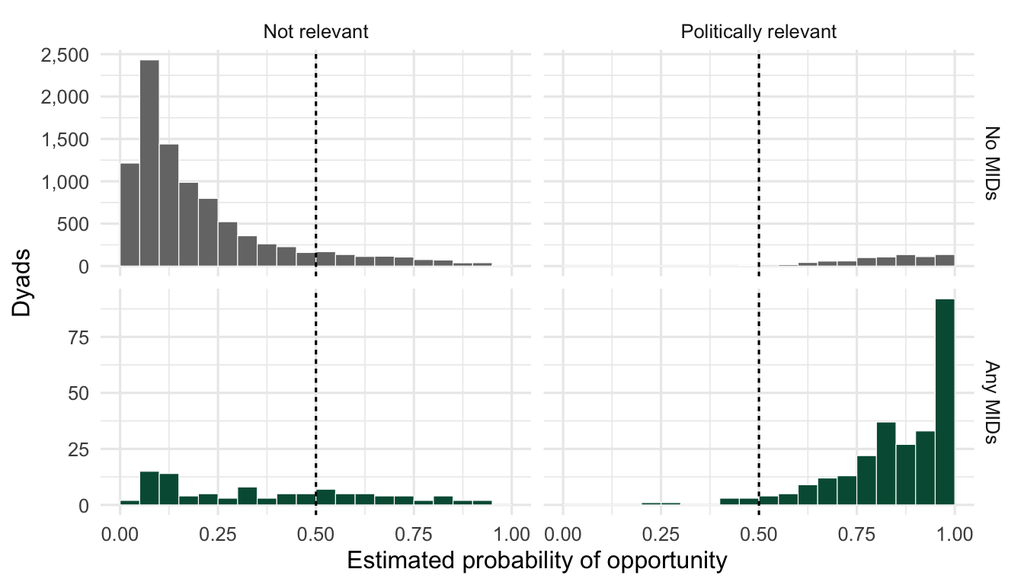

Figure 11: Estimated probability of opportunity, ZINB, for dyads the politically relevant dyads rule drops (left) and keeps (right), split by whether the dyad had any MIDs (bottom) or none (top). Each row has its own count scale. Dashed line: probability 0.5.

```r
# one histogram per cell: the rule's verdict (columns) by whether the dyad had
# any MIDs (rows); each row has its own count scale
ggplot(dy_post, aes(x = opportunity, fill = any_mid)) +
  geom_histogram(binwidth = .05, boundary = 0, color = "white", linewidth = .2) +
  geom_vline(xintercept = .5, color = bu_black, linetype = "22") +
  facet_grid(any_mid ~ rule, scales = "free_y") +
  scale_fill_manual(values = c("No MIDs" = bu_grey, "Any MIDs" = bu_green), guide = "none") +
  scale_y_continuous(labels = scales::comma) +
  labs(x = "Estimated probability of opportunity", y = "Dyads") +
  theme_bu()
```

The rule and the model mostly agree, but not at the edges. 910 dyads the rule throws away have an estimated probability of opportunity above one half — pairs of states in the same neighborhood whose capitals are close but who aren’t contiguous. 99 dropped dyads had MIDs anyway, 129 of the 971 in the data (13%), and many of them sit at a low estimated probability of opportunity — distant pairs that found a way to fight. Those are the dyads that tell us distance and major-power status don’t capture all of opportunity. The rule is a binary model of opportunity estimated by assumption; the ZINB estimates it from the data, and treats it as a probability rather than a yes or no.

Figure 12 maps the estimated probability of opportunity between two states and every other state: a major power and a regional one.

```r
world <- ne_countries(scale = "small", returnclass = "sf") %>% filter(continent != "Antarctica")

# each partner's estimated probability of opportunity with a given state
partners <- function(code) {
  dy_post %>%
    filter(ccode1 == code | ccode2 == code) %>%
    transmute(partner = if_else(ccode1 == code, ccode2, ccode1), opportunity) %>%
    mutate(iso3c = countrycode(partner, origin = "cown", destination = "iso3c", warn = FALSE))
}

opp_map <- function(code, name) {
  home <- countrycode(code, origin = "cown", destination = "iso3c")
  world %>%
    left_join(partners(code), by = c("iso_a3_eh" = "iso3c")) %>%
    ggplot() +
    geom_sf(aes(fill = opportunity), color = "white", linewidth = .1) +
    geom_sf(data = filter(world, iso_a3_eh == home), fill = bu_black, color = "white", linewidth = .1) +
    scale_fill_gradient(low = "#E8F5E9", high = bu_green, limits = c(0, 1), na.value = "grey85",
                        name = "Pr(opportunity)") +
    labs(title = name) +
    theme_void() +
    theme(legend.position = "bottom")
}

egypt_opp <- partners(651)
```

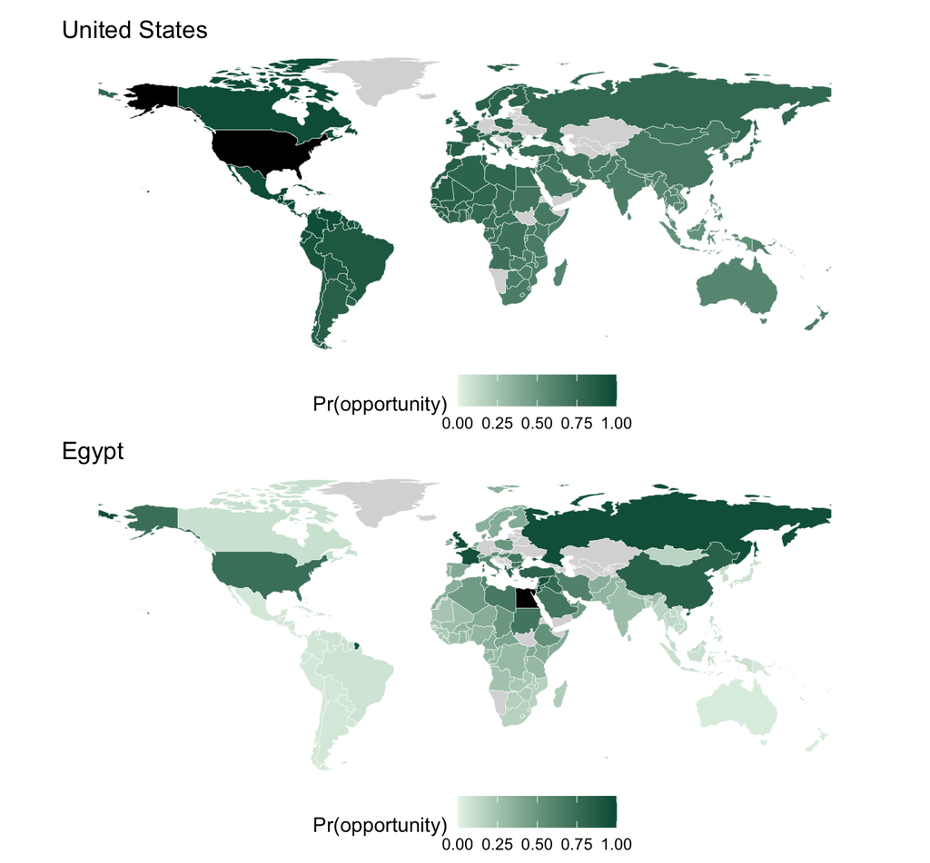

Figure 12: Estimated probability of opportunity between each state and every other state, 1951-1985, ZINB. The state itself is black; grey states have no estimate (not in the system then, or no Polity score). French Guiana, on the northeast coast of South America, is part of France in the map data, so it shows France’s value. Top: the United States. Bottom: Egypt.

```r
wrap_plots(opp_map(2, "United States"), opp_map(651, "Egypt"), ncol = 1)
```

The US, a major power, has opportunity with nearly everyone. Egypt’s is regional — its neighbors, plus the major powers, whose reach extends to Egypt. That’s the same contrast the relevant dyads rule draws by hand, but here it comes out of the data, with degrees in between.

# Opportunity, twenty years on

One of the last papers I published out of my dissertation (Clark 2003) used a zero-inflated Poisson to model US uses of force. The argument extends Fordham (1998): presidents facing economic trouble have incentives to use force abroad, but potential targets can see that, and the smart ones make themselves scarce. So the opportunity to use force is not constant, but is determined by strategic behavior; it shrinks exactly when a president most wants it. Opportunity was measured in the inflation equation — approval, Vietnam, unemployment and partisanship, the election cycle — and Fordham’s model was the count equation. Readers liked it because the model represented the data generating process: the Poisson has nowhere to put “no opportunity,” and the ZIP does. That argument still holds. But it’s worth looking at the model again with what we’ve covered this week, because it raises the question this deck has been circling: what, in the data, tells the two processes apart?

Fordham’s data aren’t posted on the course site, so the code in this section shows how the models are estimated but won’t run on your machine.

```r
# Fordham's quarterly data: US uses of force per quarter, 184 quarters
fordham <- read_dta(here::here("data", "fordham98jcr.dta")) %>% zap_labels()

Xf <- model.matrix(~ unemp + cpi + war + wecycle + pecycle + demunemp + demcpi, fordham)
Zf <- model.matrix(~ unemp + war + wecycle + pecycle + demunemp + approval + vietsynd, fordham)
yf <- fordham$force
zero_f <- yf == 0

# ZIP with a probit inflation equation, as in the paper; written on the log scale
# so it stays finite far out on the likelihood surface
zipp_ll <- function(par) {
  lambda <- as.vector(exp(Xf %*% par[1:8]))
  zi <- as.vector(Zf %*% par[9:16])
  l_psi <- pnorm(zi, log.p = TRUE)
  l_risk <- pnorm(-zi, log.p = TRUE)
  sum(ifelse(zero_f, log(exp(l_psi) + exp(l_risk - lambda)), l_risk + dpois(yf, lambda, log = TRUE)))
}

# Model 3 as published (Clark 2003, Table 1)
published <- c(-1.26, .22, -.08, -.61, .88, .00, -.04, .13,
               -9.83, 1.29, -.94, .04, -2.24, .87, -.09, 1.36)
fit_pub <- optim(published, zipp_ll, method = "BFGS",
                 control = list(fnscale = -1, maxit = 5000, reltol = 1e-12))

# the same model in pscl
m3_f <- force ~ unemp + cpi + war + wecycle + pecycle + demunemp + demcpi |
  unemp + war + wecycle + pecycle + demunemp + approval + vietsynd

# probit, started at the published values
m3_pub_start <- zeroinfl(m3_f, data = fordham, dist = "poisson", link = "probit",
                         start = list(count = published[1:8], zero = published[9:16]))

# logit, pscl's default starting values (the version in the 2024 notes), for comparison
m3_logit <- zeroinfl(m3_f, data = fordham, dist = "poisson", link = "logit")

# probit, pscl's default starting values
m3_pscl <- zeroinfl(m3_f, data = fordham, dist = "poisson", link = "probit")
par_pscl <- c(coef(m3_pscl, "count"), coef(m3_pscl, "zero"))
agree_psi_pscl <- as.vector(pnorm(Zf %*% par_pscl[9:16]))

pois_f <- glm(force ~ unemp + cpi + war + wecycle + pecycle + demunemp + demcpi, data = fordham, family = poisson)

f_labels <- c("Constant", "Unemployment", "Inflation", "Ongoing war", "Wartime election",
              "Peacetime election", "Unemployment (Democrats)", "Inflation (Democrats)",
              "Constant", "Unemployment", "Ongoing war", "Wartime election", "Peacetime election",
              "Unemployment (Democrats)", "Approval", "Vietnam syndrome")
```

## Two answers, one likelihood

```r
tibble(Stage = rep(c("Use of force (count)", "Opportunity (inflation)"), c(8, 8)),
       Variable = f_labels,
       `Published (Stata)` = published,
       pscl = par_pscl) %>%
  bind_rows(tibble(Stage = "", Variable = "ln L",
                   `Published (Stata)` = zipp_ll(published), pscl = zipp_ll(par_pscl))) %>%
  kbl(digits = 2) %>%
  kable_styling(full_width = FALSE)
```

Table 5: Model 3 of Clark (2003): the published Stata estimates and the same model estimated with pscl from its default starting values. Opportunity-stage coefficients are probits of the probability of no opportunity. Last row: the log-likelihood each set of estimates reaches on these data.

| Stage | Variable | Published (Stata) | pscl |
| --- | --- | --- | --- |
| Use of force (count) | Constant | -1.26 | -0.97 |
| Use of force (count) | Unemployment | 0.22 | 0.18 |
| Use of force (count) | Inflation | -0.08 | -0.08 |
| Use of force (count) | Ongoing war | -0.61 | -0.52 |
| Use of force (count) | Wartime election | 0.88 | 0.88 |
| Use of force (count) | Peacetime election | 0.00 | 0.07 |
| Use of force (count) | Unemployment (Democrats) | -0.04 | -0.07 |
| Use of force (count) | Inflation (Democrats) | 0.13 | 0.10 |
| Opportunity (inflation) | Constant | -9.83 | 160.37 |
| Opportunity (inflation) | Unemployment | 1.29 | 14.94 |
| Opportunity (inflation) | Ongoing war | -0.94 | -24.40 |
| Opportunity (inflation) | Wartime election | 0.04 | -30.25 |
| Opportunity (inflation) | Peacetime election | -2.24 | -9.29 |
| Opportunity (inflation) | Unemployment (Democrats) | 0.87 | 12.90 |
| Opportunity (inflation) | Approval | -0.09 | -7.66 |
| Opportunity (inflation) | Vietnam syndrome | 1.36 | -30.60 |
|  | ln L | -192.63 | -192.00 |

The two are close on the use of force and disagree completely about opportunity. `pscl`’s answer has a log-likelihood 0.63 *higher* than the published one, with opportunity-stage coefficients one or two orders of magnitude larger — approval at -7.66 instead of -0.09, a constant of 160. Coefficients that large are a warning about possible separation, and here it is: `pscl`’s answer puts the probability of no opportunity at essentially 0 or 1, and 0 of the 184 quarters fall between 0.01 and 0.99. That’s separation in the opportunity equation — the probit is sorting quarters perfectly.

Is the published answer wrong, then? No. Well, all models are wrong, so yes, but no more wrong than any other. Start `pscl` at the published values and it returns them, with the same log-likelihood (-192.58): they’re a local maximum of the same likelihood, and no coefficient moves by more than 0.004. (In fact, estimate the inflation equation as a logit rather than a probit, as in the 2024 notes, and `pscl`’s default starting values land near the published answer. The use-of-force estimates are the same, and apart from the two war terms the opportunity coefficients are about 1.6 times the probit’s, the usual logit-to-probit scale; approval is -0.15.) So this isn’t Stata against R. The same program finds different answers depending on where it starts, because the likelihood has more than one place worth stopping. Figure 13 draws it with a profile likelihood.

**What is a profile likelihood?**

The log-likelihood here is a function of 16 parameters at once, so we can’t draw it. A **profile likelihood** draws it for one parameter at a time. Pick a value for the parameter we care about — here, the coefficient on approval — and hold it fixed. Maximize the log-likelihood over all the *other* parameters, and record that maximum. Then move to the next value and do it again. The result is a curve: for each value of the one parameter, the best the model can do when that parameter is forced to take that value and everything else is free to adjust.

Read it the way we read the log-likelihood curves in the likelihood notes. The peak is the maximum likelihood estimate. The shape says how much the data tell us. A sharp peak means values away from the estimate fit much worse, so the parameter is well identified. A flat stretch means the data can’t tell those values apart, because the other parameters shift to compensate. The curve also gives a confidence interval without assuming the estimate’s sampling distribution is normal: the values whose profile log-likelihood is within 1.92 of the peak (half of 3.84, the 95% critical value of a $\chi^2$ with one degree of freedom) form a 95% interval. That’s the profile-likelihood interval Firth’s method reported in Week 4.

Each point is its own maximization over 15 parameters, and on a surface this irregular a single starting value can stall below the top. So each point is fit from several starting values, including its neighbors’ solutions, and the best is kept. The light line through the points shows they trace a single function.

```r
# profile likelihood for the approval coefficient: fix it, maximize over the rest.
# On a surface this irregular one start can stall below the top, so each point is
# fit several ways -- from the published and separation solutions, sweeping the grid in
# both directions with each fit starting where the last ended, then again from
# each neighbor's best fit -- and the best value is kept
k_app <- 15
mean_app <- mean(fordham$approval)

fit_at <- function(val, st) {
  st[9] <- st[9] + (st[k_app] - val) * mean_app      # re-center the constant
  st[k_app] <- val
  fn <- function(p) zipp_ll(append(p, val, after = k_app - 1))
  o <- optim(st[-k_app], fn, method = "BFGS", control = list(fnscale = -1, maxit = 5000, reltol = 1e-12))
  o <- optim(o$par, fn, method = "Nelder-Mead", control = list(fnscale = -1, maxit = 20000))
  o <- optim(o$par, fn, method = "BFGS", control = list(fnscale = -1, maxit = 5000, reltol = 1e-12))
  list(ll = o$value, par = append(o$par, val, after = k_app - 1))
}

app_grid <- c(-10, -9, -8, -7, -6, -5, -4, -3.5, -3, -2.5, -2, -1.5, -1, -.75, -.5, -.4, -.3,
              -.2, -.15, -.1, -.05, 0, .05)
best_ll <- rep(-Inf, length(app_grid))
best_par <- vector("list", length(app_grid))
keep <- function(i, f) if (f$ll > best_ll[i]) { best_ll[i] <<- f$ll; best_par[[i]] <<- f$par }

for (start in list(fit_pub$par, par_pscl)) {
  for (ord in list(seq_along(app_grid), rev(seq_along(app_grid)))) {
    st <- start
    for (i in ord) { f <- fit_at(app_grid[i], st); keep(i, f); st <- f$par }
  }
}
for (pass in 1:3) {
  for (i in seq_along(app_grid)) {
    for (nb in intersect(c(i - 1, i + 1), seq_along(app_grid))) keep(i, fit_at(app_grid[i], best_par[[nb]]))
  }
}

prof <- tibble(approval = app_grid, ll = best_ll) %>%
  mutate(rel = ll - max(ll))

# where the profile peaks, and what the opportunity equation does there
top <- which.max(best_ll)
psi_top <- as.vector(pnorm(Zf %*% best_par[[top]][9:16]))
valley <- min(prof$rel[prof$approval > -1 & prof$approval < -.1])
```

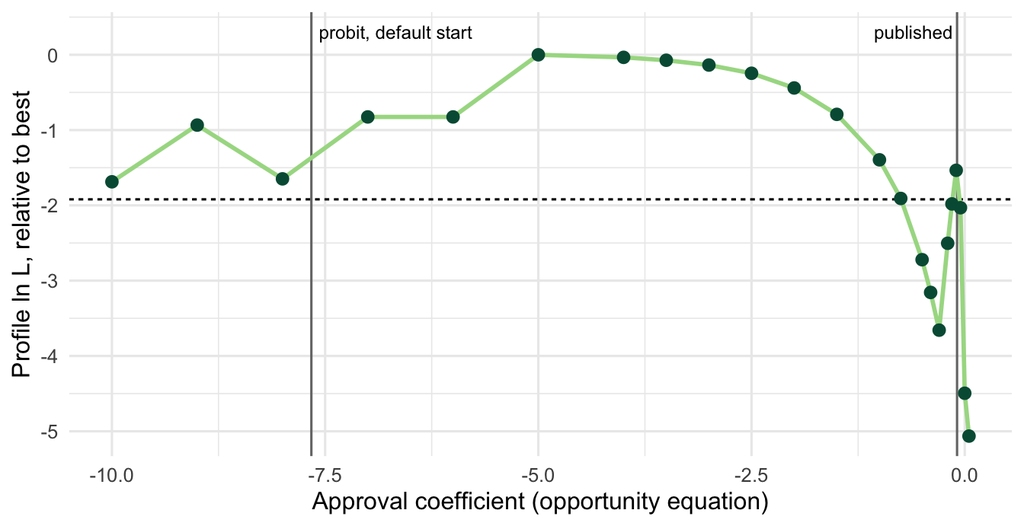

Figure 13: Profile log-likelihood for the approval coefficient in the opportunity equation: at each fixed value, the best log-likelihood found over all other parameters, relative to the highest value found. The light line connects the points to show they trace one function; each point is the best of several fits, and could still sit slightly below the true curve. Dashed line: 1.92 below the highest value found, the edge of a 95% profile interval. Vertical lines mark the published estimate and the probit fit from pscl’s default starting values.

```r
ggplot(prof, aes(x = approval, y = rel)) +
  geom_hline(yintercept = -1.92, color = bu_black, linetype = "22") +
  geom_vline(xintercept = c(published[15], par_pscl[15]), color = bu_grey) +
  geom_line(color = bu_palegreen, linewidth = 1) +
  geom_point(color = bu_green, size = 2.4) +
  annotate("text", x = published[15], y = .3, label = "published", hjust = 1.05, size = 3.2, color = bu_black) +
  annotate("text", x = par_pscl[15], y = .3, label = "probit, default start", hjust = -.05, size = 3.2, color = bu_black) +
  labs(x = "Approval coefficient (opportunity equation)", y = "Profile ln L, relative to best") +
  theme_bu()
```

**Why doesn’t an optimizer find that higher ground?** Because there’s no top up there to find. Each point on the plateau sorts the quarters into “certainly no opportunity” and “at risk,” and the log-likelihood keeps creeping up as the opportunity coefficients grow without bound, so the slope flattens out and the optimizer stops on it — separation again. Getting from one sorting to another, or from the published solution across the valley, means going downhill first, which a hill climber won’t do. “It converged” means the slope got small, not that we found the maximum.

So the data identify the *sign* of approval’s effect on opportunity, and not its size. Most of the range from −10 to about −1 clears the dashed line, and so does the bump around −0.1; the valley between them and everything at zero or above do not. The published estimate is the sensible interior answer, but the likelihood alone doesn’t single it out — and the likelihood’s highest ground is a set of degenerate ridges with no top.

Why? Two reasons. First, there aren’t many excess zeros to work with. A plain Poisson predicts 50% zeros; the data have 52%. The ZIP is splitting a small surplus of zeros across 184 quarters. Second, what identifies the split is mostly the **exclusion restrictions** — approval and Vietnam syndrome are in the opportunity equation but not the count equation — and the functional form. Take the exclusions away and only functional form is left. A reviewer asked me to do exactly that, and footnote 22 of the paper reports what happened: estimates and z-scores “reach extraordinarily large values in the splitting stage of the model.”

```r
m_same <- zeroinfl(force ~ unemp + cpi + war + wecycle + pecycle + demunemp + demcpi + approval + vietsynd |
                     unemp + cpi + war + wecycle + pecycle + demunemp + demcpi + approval + vietsynd,
                   data = fordham, dist = "poisson", link = "probit")

tibble(Variable = names(coef(m_same, "zero")), `Opportunity-stage estimate` = coef(m_same, "zero")) %>%
  kbl(digits = 1) %>%
  kable_styling(full_width = FALSE)
```

Table 6: The opportunity stage with the same covariates in both equations (no exclusion restrictions), pscl, probit.

| Variable | Opportunity-stage estimate |
| --- | --- |
| (Intercept) | 289.7 |
| unemp | 10.7 |
| cpi | -2.9 |
| war | -13.1 |
| wecycle | -200.2 |
| pecycle | -46.0 |
| demunemp | 17.2 |
| demcpi | -10.3 |
| approval | -9.8 |
| vietsynd | 74.4 |

## What I’d do differently now

I’d still estimate the ZIP. The theory is about opportunities to use force abroad, and a model with a place for “no opportunity” represents it; the Poisson doesn’t. Part of my motive was that I just don’t buy most diversionary war claims, for several reasons, one being that I’m not persuaded diversion is as easy as the literature makes it out to be. The states that are likely to be convenient scapegoats know who they are and have incentives not to become actual targets. Things I’d change:

- **Say what identifies the split, and tie it to the two processes.** The zeros and the counts come from related but different processes: whether potential targets make themselves available, and whether a president facing economic trouble uses force when they do. In these data the split is identified by the exclusion restrictions and functional form, not by a surplus of zeros. Approval and Vietnam belong in the opportunity equation and not the use-of-force equation because, in the argument, they shape how potential targets read the president. That’s the claim the identification rests on, and I’d defend it explicitly rather than leave it implicit.
- **Explain the reviewer’s model as an identification check.** Identical equations producing absurd estimates is evidence about what identifies the split, not a rival model. The risk is that readers who see those estimates conclude the model is broken, so the reason has to sit right next to them — today in an online appendix, which few journals offered then.
- **Interpret the predictions, and be modest about the inflation coefficients.** Expected uses of force are fairly stable across solutions; the size of approval’s effect on opportunity is not. Signs, yes; magnitudes, carefully.
- **Don’t lean on the Vuong test.** It was the standard advice when I wrote the paper: Greene (1994) brought it to zero-inflated models, and Stata’s `zip` command offered it as an option. Later work showed it’s biased toward finding zero inflation (Desmarais and Harden 2013) and is the wrong test when one model is nested in the other (Wilson 2015); Stata dropped the option in version 15. There’s still no clean test of a ZIP against a Poisson when the inflation equation has covariates, so I’d make the case from theory, information criteria, and where the model puts the zeros.
- **Check the answer more than one way.** Different starting values and links, and a profile likelihood for the coefficients the argument rests on. A model that converges quickly can still be sitting on one of several plausible stopping points. I didn’t know how to do this back then.
- **The constituent term.** Fordham’s specification interacts unemployment and inflation with party but leaves out the party main effect (interactions). In principle it belongs. Including it would have opened a debate about Fordham’s specification that I didn’t care much about, and drawn readers away from the argument about strategic behavior. That’s a real tradeoff in writing a paper: which fights to have.

There’s a professionalization lesson to be had as well. When you write a paper, you know what you know. Be as careful as you can be, but recognize that you will learn things and change how you think, and the discipline will change. When I wrote this paper (2001–02), practically no one put confidence bands around predictions. King, Tomz, and Wittenberg (2000) had just shown how to simulate them and released Clarify to do it, so the norm was going to change, but that took time. Replication materials usually included the models, not the figures (I don’t have original code for the figures, but have re-created them in R). Interactions were routinely interpreted incorrectly, and omitting constituents was not uncommon. That left space for Brambor, Clark, and Golder (2006) to point out the interpretation problems and provide solutions.

Anyhow, all models are wrong, but some are useful (Box and Draper 1987, 424). The goal is to generate research that’s useful.

# Split populations elsewhere

- **Competing risks** (Week 5): one coefficient on “leaving office” averaged opposite effects on regular and irregular exits (competing risks) — the hurdle coefficients’ lesson.
- **Split-population duration models** (Week 11): some units never fail; a binary equation for being at risk and a hazard for when at-risk units fail, the zero-inflated structure again (Clark and Regan 2003; Bagozzi et al. 2019).
- **Ordered outcomes**: the zero-inflated ordered probit (Bagozzi et al. 2015).
- **Truncation and censoring**: the hurdle’s count part is a truncated distribution, renormalized over what we can see.

# A comment on software

The zero-altered models are mainly estimable in R using either `pscl` or `glmmTMB`. The former is Simon Jackman’s political science package; its `zeroinfl()` and `hurdle()` functions were written with Achim Zeileis and Christian Kleiber (Zeileis, Kleiber, and Jackman 2008). The latter is a package aimed at multi-level estimation (e.g., random effects). Results from the two do not always correspond. Moreover, models that converge easily in Stata do not always converge in R — I’m making no judgment regarding what’s right here. As the Fordham example shows, different answers — from different programs, links, or starting values — can be a symptom of a likelihood with more than one place to stop, rather than a bug in anything. Check which way the binary equation runs: `zeroinfl()` and Stata’s `zinb` model a structural zero, `hurdle()` models clearing the hurdle.

# Take away points

- Zeros can come from more than one process. Opportunity and willingness is the classic political science case: some dyads never have the chance to fight.
- The negative binomial is a continuous mixture; the zero-inflated Poisson a discrete one. Structural zeros alone produce overdispersion: $var/E = 1 + \psi\lambda$.
- Zero-inflated: structural and sampling zeros; the likelihood doesn’t separate; the binary equation’s signs run backwards. Hurdle: one kind of zero, a truncated count, a likelihood that separates.
- For a single unit, a ZIP and a hurdle Poisson can be the same distribution. Theory chooses: can an at-risk unit still have a zero?
- The Poisson is a cloglog hurdle with one $\beta$ for both parts. In the dyads, democracy and distance govern whether pairs fight at all, not how often.
- In the ZINB, distance moves into the opportunity equation; democracy stays in willingness, by the exclusion restriction. The hurdle puts democracy in whether dyads fight at all. The two binary equations estimate different quantities. The relevant dyads rule is a hand-coded inflation equation; the model estimates it.
- Two linear predictors, two channels: $\partial E[y]/\partial x_k = E[y](\beta_k - \psi\gamma_k)$. Simulate the quantities.
- Ask what identifies the split: excess zeros, exclusion restrictions, or only functional form. Predictions can be well identified when the split isn’t.

# Coming up next

Next week we go back to the connection between counts and hazards — the same events counted per period and timed between occurrences — and follow it toward the duration models of Week 11, where split populations return.

# References

Bagozzi, Benjamin E. 2015. “Forecasting Civil Conflict with Zero-Inflated Count Models.” *Civil Wars* 17 (1): 1–24.

Bagozzi, Benjamin E., Daniel W. Hill, Will H. Moore, and Bumba Mukherjee. 2015. “Modeling Two Types of Peace: The Zero-Inflated Ordered Probit (ZiOP) Model in Conflict Research.” *Journal of Conflict Resolution* 59 (4): 728–52.

Bagozzi, Benjamin E., Minnie M. Joo, Bomin Kim, and Bumba Mukherjee. 2019. “A Bayesian Split Population Survival Model for Duration Data with Misclassified Failure Events.” *Political Analysis* 27 (4): 415–34.

Box, George E. P., and Norman R. Draper. 1987. *Empirical Model-Building and Response Surfaces*. New York: Wiley.

Brambor, T., W. R. Clark, and M. Golder. 2006. “Understanding Interaction Models: Improving Empirical Analyses.” *Political Analysis* 14 (1): 63–82.

Casiraghi, Matteo C. M., and Eugenio Cusumano. 2024. “Lethal Brands: Terrorist Groups’ Logos and Violence.” *Journal of Peace Research* 61 (6): 917–32. https://doi.org/10.1177/00223433231168181.

Clark, David H. 2003. “Can Strategic Interaction Divert Diversionary Behavior? A Model of US Conflict Propensity.” *Journal of Politics* 65 (4): 1013–39.

Clark, David H., and Patrick M. Regan. 2003. “Opportunities to Fight: A Statistical Technique for Modeling Unobservable Phenomena.” *Journal of Conflict Resolution* 47 (1): 94–115. https://doi.org/10.1177/0022002702239513.

Desmarais, Bruce A., and Jeffrey J. Harden. 2013. “Testing for Zero Inflation in Count Models: Bias Correction for the Vuong Test.” *Stata Journal* 13 (4): 810–35.

Fordham, Benjamin. 1998. “Partisanship, Macroeconomic Policy, and u.s. Uses of Force, 1949-1994.” *Journal of Conflict Resolution* 42 (4): 418–39.

Gibler, Douglas M., Steven V. Miller, and Erin K. Little. 2016. “An Analysis of the Militarized Interstate Dispute (MID) Dataset, 1816–2001.” *International Studies Quarterly* 60 (4): 719–30.

Greene, William H. 1994. “Accounting for Excess Zeros and Sample Selection in Poisson and Negative Binomial Regression Models.” Working Paper EC-94-10. New York University, Stern School of Business.

King, Gary, Michael Tomz, and Jason Wittenberg. 2000. “Making the Most of Statistical Analyses: Improving Interpretation and Presentation.” *American Journal of Political Science* 44 (2): 347–61.

Kleiber, Christian, and Achim Zeileis. 2016. “Visualizing Count Data Regressions Using Rootograms.” *The American Statistician* 70 (3): 296–303.

Lambert, Diane. 1992. “Zero-Inflated Poisson Regression, with an Application to Defects in Manufacturing.” *Technometrics* 34 (1): 1–14. https://doi.org/10.2307/1269547.

Lemke, Douglas, and William Reed. 2001. “The Relevance of Politically Relevant Dyads.” *Journal of Conflict Resolution* 45 (1): 126–44.

Miller, Steven V. 2022. “Peacesciencer: An R Package for Quantitative Peace Science Research.” *Conflict Management and Peace Science* 39 (6): 755–79. https://doi.org/10.1177/07388942221077926.

Most, Benjamin A., and Harvey Starr. 1989. *Inquiry, Logic and International Politics*. Columbia, SC: University of South Carolina Press.

Mullahy, John. 1986. “Specification and Testing of Some Modified Count Data Models.” *Journal of Econometrics* 33 (3): 341–65.

Pohlmeier, Winfried, and Volker Ulrich. 1995. “An Econometric Model of the Two-Part Decisionmaking Process in the Demand for Health Care.” *Journal of Human Resources* 30 (2): 339–61.

Vuong, Quang H. 1989. “Likelihood Ratio Tests for Model Selection and Non-Nested Hypotheses.” *Econometrica* 57 (2): 307–33.

Wilson, Paul. 2015. “The Misuse of the Vuong Test for Non-Nested Models to Test for Zero-Inflation.” *Economics Letters* 127: 51–53. https://doi.org/10.1016/j.econlet.2014.12.029.

Zeileis, Achim, Christian Kleiber, and Simon Jackman. 2008. “Regression Models for Count Data in R.” *Journal of Statistical Software* 27 (8): 1–25. https://doi.org/10.18637/jss.v027.i08.

Zorn, Christopher J. W. 1998. “An Analytic and Empirical Examination of Zero-Inflated and Hurdle Poisson Specifications.” *Sociological Methods and Research* 26 (3): 368–400.

Back to top